# **Cyclistic Bike Sharing Data Analysis**

## Google Data Analytics Capstone Project by Avaes Shah

```r
## Build the program environment - loading libraries for cleaning and analysis

ipak <- function(pkg){
new.pkg <- pkg[!(pkg %in% installed.packages()[, "Package"])]
if (length(new.pkg))
    install.packages(new.pkg, dependencies = TRUE)
sapply(pkg, require, character.only = TRUE)
}

# load packages
packages <- c("ggplot2", "tidyverse", "geosphere", "dplyr", "readr", "lubridate", "janitor", "hms", "skimr", "here", "viridis", "hrbrthemes", "ggrepel")
ipak(packages)
```

```
   ggplot2  tidyverse  geosphere      dplyr      readr  lubridate    janitor
      TRUE       TRUE       TRUE       TRUE       TRUE       TRUE       TRUE
       hms      skimr       here    viridis hrbrthemes    ggrepel
      TRUE       TRUE       TRUE       TRUE       TRUE       TRUE
```

## Introduction

This project is part of the Google Data Analytics Certification. The project features a business problem faced by a fictitious company “Cyclistic”. The project details can be found here. The aim of this project is demonstrate knowledge and skills in data analytics to solve a business problem. This project will take you through the 6 phases of data analysis pipeline:

- **Phase 1 : Ask**
- **Phase 2 : Prepare**
- **Phase 3 : Process**
- **Phase 4 : Analyse**
- **Phase 5 : Share**
- **Phase 6 : Act**

# **Phase 1 : Ask**

### **Stakeholders**

**Client**: Cyclistic  
**Sector**: Personal Transportation Hire (Bicycle)  
**Department**: Marketing  
**Analyst(s)**: Avaes Shah  
**Project Start Date**: 03/02/23  
**Estimated Project Due Date**: 20/03/23  
**Stakeholder(s)**:  
- Lily Moreno (Director of Marketing and Data Analytics Team Manager)  
- Cyclistic marketing analytics team  
- Cyclistic executive team

### **Statement of Business Task**

Cyclistic is a bike sharing company based in Chicago. The service is offered to two types of customers: subscribers known as annual members and casual riders.

The financial team have shown that annual members are more profitable than causal riders.

The marketing director wants to target a marketing campaign aimed at the causal riders to switch to an annual membership.

In order to convert casual riders to annual member riders, we need to study the bike usage patterns for both casual and member riders and identify where the two are similar. That will allow us to identify the segment of casual riders who use hire their bikes repeatedly as they would benefit most from the annual membership.

The results from this analysis will first be presented to the stakeholders for their approval, and based on the recommendations of this study the marketing team will design their campaign.

**Business task**: To draw insights from Cyclistic’s historical trip data to see how annual members and casual riders use bikes differently for the period between 1st Jan 2022 to 31st Dec 2022. The analysis findings will drive the direction and design of the marketing campaign moving forward. The question to be answered:

**1.How do annual members and causal riders use Cyclistic bikes differently?**

**Deliverables**:

1. Statement of business task
2. Documentation report of cleaning or manipulation of data (changelog)
3. Analysis summary
4. Suppporting visualisations and key findings
5. Top 3 recommendations based on the analysis

# **Phase 2 : Prepare**

**The Dataset**

The 2022 dataset has been provided in CSV format. They are in 12 separate zip files, one for each month of 2022. There is no encryption or passwords on these files or dataset. Each file contains Cyclistic trip data in CSV format.

Source provided for dataset: https://divvy-tripdata.s3.amazonaws.com/index.html

**The Change Log**

Any changes made to the original dataset will be recorded in the following change log file: **cyclistic_change_log.txt**

**Dataset Storage**

I have downloaded the 12 zip files to a folder: “Cyslistic” on my local computer hardrive. Subsquently I have uncompressed the 12 CSV files into the folder “Cyclistic”.

**Data Integrity**

Does the Dataset ROCCC ?

- Reliable: The dataset appears to be first-party data and is computer generated by bike bookings and usage. The data is generated by Cyclistic’s own systems and is held on their own servers (internal data) Upon examination however I noticed that some of the start and end station names were missing. The dataset’s reliability will need to be assessed through a series of SQL queries in Google BigQuery. A report to follow.
- Original: The data is original because it belongs to the company Cyclist and has not been purchased from a third-party. The data is computer generated by the bikes and stations and held and maintained on the Cyclistic ’s own data servers.
- Comprehensive: The data is comprehensive but the customer data portion has been censored under data protection. The business task requires comparisions of various metrics, which will need to be calculated and/or derived from the original dataset. The financial data and customer demographic data is absent, other than that the current dataset will be sufficient to carry out the initial business task.
- Current: Yes: The last trip data was uploaded in December 2022.
- Cited: This data is cited as first-party data belonging to Cyclist and is not from a third party.

**Data Licencing**

The data belongs to Bikeshare and is publicly licenced as open-source:

**Licence**: “*Bikeshare hereby grants to you a non-exclusive, royalty-free, limited, perpetual license to access, reproduce, analyze, copy, modify, distribute in your product or service and use the Data for any lawful purpose (“License”).*”

Link to full licence: https://ride.divvybikes.com/data-license-agreement

**Data Bias**

- Sampling Bias – The data is representative of 100% of the population (all customers using the bikes) and no sample has been taken which would eliminate sampling bias.
- Confirmation/interpretation bias – The data is automatically generated through the use of the bikes. The data, which includes the above metrics, do not have any human intervention when collecting the data, therefore human error would not come into play here.
- Observer bias (experimenter/research bias) – n/a here as this data is computer generated and logged straight into the system with no human intervention to my knowledge.

**Data Ethics**

The reliability of the data collection would fall upon the system recording the data. There would appear to be missing data in some fields of end_station_name/start_station as some cells have been left blank, however we will attempt to reconstruct the missing data referencing the existing data with the GPS coordinates of the missing observations. A full report to follow.

**Privacy**

The original dataset contained Cyclistic user personal and financial data, this has been removed to protect the privacy of the users under data privacy legislation. Their financial and home address has been removed to protect their privacy prior to the dataset being hosted on an opensource public licence. The redacted data will would have allowed us to see the customer demographic information, but the protection of the customer’s details takes priority under data protection laws. We still have the necessary information to answer the business task.

**Ownership**

Control and ownership remains with Cyclistic company. The licencing for the trip dataset is exclusively controlled and owned by them.

**Transaction transparency / consent / currency**

The customers of Cyclistic would have been provided a declaration stating how their data will be used. They would have had to read and agreed with this statement before using the bikes. All customers who use Cyclistic have agreed to this declaration. The user reserves the legal right to request their personal information at anytime from Cyclistic.

**Openness**

Cyclistic has made its trip data publicly available after the customer details have been removed.

**Proposed tools**

The data sets are quite large, July 2020 dataset having nearly 800,000 rows. The best tools to handle large datasets would be BigQuery Data Warehouse (SQL) for data pre-cleaning, integrity/credibility testing, validation and R Studio for the analysis & visualisation. Tableau will also be used to support the visualisation deliverables.

## **Data Credibility & Integrity Testing**

### **Testing Plan**

Here we will upload the 12 raw dataset files into BigQuery and perform tests in SQL to determine the integrity and credability of the dataset.

We will be testing the dataset for:

- duplicates
- errors
- missing values
- nulls
- regular expression
- data type inconsistencies
- data range conformity
- data accuracy
- data completness

the validation and integrity testing will be carried out in BigQuery, which I shall refer to as the pre-cleaning. The cleaning process where manipulation of the data cannot be completed in BigQuery due to the restrictions on write processes under the free licence terms of use. Hence the exporting of the dataset to CSV where the dataset will be imported and cleaned using R Studio.

### **Cyclistic Integrity Report**

The full report can be found [here](https://shazee786.github.io/cyclistic_data_analysis/)

#### **Integrity & Credibility Report Summary**

1. 8 records with GPS coordinates missing for the end station Green St & Madison Ave* will be kept with the exported table. We can fill these end GPS coordinates with the average GPS values for this end station in R Studio. They cannot be performed here due to limitation of the free licence.
2. 5858 records with end station information missing (name, id, GPS coordinates) will need to be filtered out.
3. Missing records. There is on average 15% of the station name and ids missing (see below). The GPS coordinates are however present and it may be possible from the cleaning process to identify the average GPS coordinates for the stations and match them with the GPS coordinates of the missing records to fill those values.

   | Field | Missing Records | % of dataset |
   | --- | --- | --- |
   | start_station_name | 833064 | 14.70 |
   | start_station_id | 833064 | 14.70 |
   | end_station_name | 892742 | 15.75 |
   | end_station_id | 892742 | 15.75 |

   These missing values do not prevent us from carrying out the analysis as we have the GPS coordinates to rely on if geometrical data is required.
4. The other metrics in the dataset appear to be clean and have passed the validation tests.

#### **Data Integrity Report Conclusion**

The data is dirty and requires cleaning. There are a number of actions in the cleaning process to carry out which I will outline in the process phase of the analysis.

# **Phase 3 : Process**

### **Cleaning Action Plan**

These items listed will be referenced throughout the cleaning process as item 1, item 2 etc

1. Upload dataset (cyclistic_trip_pre_clean_2022.csv) into a data frame
2. Update the end station (Green St & Madison Ave*) GPS coordinates
3. Clean datatset:
- Fill missing end and start station names and ids using existing station data from the dataset with average GPS coordinates as reference
- Remove any blank spaces from the end/start station names
- Convert station names and ids to lowercase
4. Create calculated and derived columns:
- **route** [chr] - the route from the start station to the end station
- **start_time** [chr] - this is the time component in hh:mm:ss format for the started_at datetime object
- **end_time** [chr] - same as above but for the ended_at datetime object
- **trip_dur_min**[integer] - trip length in minutes (ended_at - started_at)
- **trip_dur_sec**[integer] - trip length in seconds (ended_at - started_at)
- **weekday** [ordered factor] - the weekday of hire
- **month** [ordered factor] - month of hire
- **year** [int] - year of hire
- **date** [chr] - start date of hire
- **stn_dist_km** [number] - this is the distance (km) between the start and end station “as the crow flies”

### **Action Plan Item 1 : Upload Dataset**

We first import the pre-cleaned data from CSV file to a data frame

```r
## upload pre-cleaned dataset to dataframe for cleaning

trip_df <- read.csv("cyclistic_trip_pre_clean_2022.csv")
```

```r
## check the dataset structure

head(trip_df)
```

```
           ride_id rideable_type              started_at
1 A1551C2A6CC01116   docked_bike 2022-01-22 09:26:28 UTC
2 65B3C94D70B436CA   docked_bike 2022-02-10 10:40:40 UTC
3 E3A5964161B3512C   docked_bike 2022-02-17 21:13:48 UTC
4 466E2D0B378E0FEB   docked_bike 2022-04-23 17:30:58 UTC
5 7DE3366980BFC22F   docked_bike 2022-04-05 13:56:37 UTC
6 5E1D18F847367D19   docked_bike 2022-04-04 17:42:27 UTC
                 ended_at          start_station_name start_station_id
1 2022-01-22 09:36:48 UTC    Elston Ave & Cortland St     TA1305000039
2 2022-02-10 10:56:01 UTC   Western Ave & Division St            13241
3 2022-02-17 21:58:57 UTC   Clark St & Wellington Ave     TA1307000136
4 2022-04-23 17:56:19 UTC Sheridan Rd & Noyes St (NU)              604
5 2022-04-05 14:42:33 UTC       Michigan Ave & 8th St              623
6 2022-04-04 18:13:38 UTC     Streeter Dr & Grand Ave            13022
                     end_station_name end_station_id start_lat start_lng
1        Sheffield Ave & Kingsbury St          13154  41.91643 -87.66675
2       Greenview Ave & Fullerton Ave   TA1307000001  41.90289 -87.68727
3             Western Ave & Walton St   KA1504000103  41.93650 -87.64754
4           Chicago Ave & Sheridan Rd           E008  42.05824 -87.67743
5 Mies van der Rohe Way & Chicago Ave          13338  41.87277 -87.62398
6       Michigan Ave & Ida B Wells Dr   TA1305000010  41.89228 -87.61204
   end_lat   end_lng member_casual
1 41.91052 -87.65311        casual
2 41.92533 -87.66580        casual
3 41.89842 -87.68660        casual
4 42.05049 -87.67782        casual
5 41.89695 -87.62176        casual
6 41.87624 -87.62443        casual
```

```r
#check the column names

colnames(trip_df)
```

```
 [1] "ride_id"            "rideable_type"      "started_at"
 [4] "ended_at"           "start_station_name" "start_station_id"
 [7] "end_station_name"   "end_station_id"     "start_lat"
[10] "start_lng"          "end_lat"            "end_lng"
[13] "member_casual"
```

### **Action Plan Item 2 : Update Green St & Madison Ave* GPS coordinates**

We identify the rows where the end station GPS coordinates = 0.0

```r
filter(trip_df, end_lng==0.0)
```

```
           ride_id rideable_type              started_at
1 E9495F1DC3475D41  classic_bike 2022-11-09 12:21:55 UTC
2 3B47B333C0D186F0  classic_bike 2022-11-09 13:39:03 UTC
3 6AFE1471227BD76F  classic_bike 2022-11-09 16:17:16 UTC
4 BB8AA29838266294  classic_bike 2022-11-09 11:32:53 UTC
5 7F49424E860E7094  classic_bike 2022-11-09 13:27:04 UTC
6 0A6988FE859F4D54  classic_bike 2022-11-09 10:58:37 UTC
7 75DE33501313D0CE  classic_bike 2022-11-09 15:52:08 UTC
8 42AF82C53D831251 electric_bike 2022-11-09 16:17:40 UTC
                 ended_at            start_station_name start_station_id
1 2022-11-09 12:26:18 UTC     Aberdeen St & Randolph St            18062
2 2022-11-09 13:44:38 UTC Franklin St & Adams St (Temp)     TA1309000008
3 2022-11-09 16:26:17 UTC           Morgan St & Polk St     TA1307000130
4 2022-11-09 11:37:30 UTC           Canal St & Adams St            13011
5 2022-11-09 13:28:28 UTC    Green St & Washington Blvd            13053
```

[output cut: 21 more lines]

This brings up the 8 records with incorrect GPS coordinates for the end station. We can now proceed and update the trip_df dataset with the average GPS values for the end station:

```r
# update the GPS coordinates for Green St & Madison Ave* end latitude

trip_df$end_lat[trip_df$end_lat == 0] <- 41.881827586351044

# do the same for the end longitude ...
trip_df$end_lng[trip_df$end_lng == 0] <- -87.648832371179864
```

We can test that the values have been updated with a filter. The correct result should be no results !

```r
# check if there is any end longitude GPS coordinates with the incorrect value 0.0
filter(trip_df, end_lng==0.0)
```

```
 [1] ride_id            rideable_type      started_at         ended_at
 [5] start_station_name start_station_id   end_station_name   end_station_id
 [9] start_lat          start_lng          end_lat            end_lng
[13] member_casual
<0 rows> (or 0-length row.names)
```

```r
# and the same for the the end latitude ...
filter(trip_df, end_lat==0.0)
```

```
 [1] ride_id            rideable_type      started_at         ended_at
 [5] start_station_name start_station_id   end_station_name   end_station_id
 [9] start_lat          start_lng          end_lat            end_lng
[13] member_casual
<0 rows> (or 0-length row.names)
```

There are no results, which means the incorrect GPS values for the 8 records have been updated successfully.

### **Action Plan Item 3 : Clean Dataset**

Let us start by converting columns: start_station_name, start_station_id, end_station_name, end_station_id to lowercase for ease of readability.

```r
# convert start/end station name and id columns to lowercase

# start station
trip_df$start_station_name <- tolower(trip_df$start_station_name)
trip_df$start_station_id <- tolower(trip_df$start_station_id)

# end station
trip_df$end_station_name <- tolower(trip_df$end_station_name)
trip_df$end_station_id <- tolower(trip_df$end_station_id)

tibble(trip_df)
```

```
# A tibble: 5,661,859 × 13
   ride_id       ridea…¹ start…² ended…³ start…⁴ start…⁵ end_s…⁶ end_s…⁷ start…⁸
   <chr>         <chr>   <chr>   <chr>   <chr>   <chr>   <chr>   <chr>     <dbl>
 1 A1551C2A6CC0… docked… 2022-0… 2022-0… elston… ta1305… sheffi… 13154      41.9
 2 65B3C94D70B4… docked… 2022-0… 2022-0… wester… 13241   greenv… ta1307…    41.9
 3 E3A5964161B3… docked… 2022-0… 2022-0… clark … ta1307… wester… ka1504…    41.9
 4 466E2D0B378E… docked… 2022-0… 2022-0… sherid… 604     chicag… e008       42.1
 5 7DE3366980BF… docked… 2022-0… 2022-0… michig… 623     mies v… 13338      41.9
 6 5E1D18F84736… docked… 2022-0… 2022-0… street… 13022   michig… ta1305…    41.9
 7 09789540AF1E… docked… 2022-0… 2022-0… clark … 13179   wabash… ta1307…    41.9
 8 5A17C0D66E33… docked… 2022-0… 2022-0… wood s… 13221   wells … ta1308…    41.9
 9 8A0E79973315… docked… 2022-0… 2022-0… dusabl… 13300   sedgwi… ta1307…    41.9
10 16D2DF0667CF… docked… 2022-0… 2022-0… rush s… 15530   lincol… ta1309…    41.9
# … with 5,661,849 more rows, 4 more variables: start_lng <dbl>, end_lat <dbl>,
#   end_lng <dbl>, member_casual <chr>, and abbreviated variable names
#   ¹rideable_type, ²started_at, ³ended_at, ⁴start_station_name,
#   ⁵start_station_id, ⁶end_station_name, ⁷end_station_id, ⁸start_lat
```

Now we remove any white spaces from columns start_station_name, start_station_id, end_station_name, end_station_id for ease of readability and consistency.

```r
## remove the leading and trailing white spaces from the start and end station name and id columns

# start station
trip_df$start_station_name <- trimws(trip_df$start_station_name, which = c("both"), whitespace = "[ \t\r\n]")
trip_df$start_station_id <- trimws(trip_df$start_station_id, which = c("both"), whitespace = "[ \t\r\n]")

# end station
trip_df$end_station_name <- trimws(trip_df$end_station_name, which = c("both"), whitespace = "[ \t\r\n]")
trip_df$end_station_id <- trimws(trip_df$end_station_id, which = c("both"), whitespace = "[ \t\r\n]")

tibble(trip_df)
```

```
# A tibble: 5,661,859 × 13
   ride_id       ridea…¹ start…² ended…³ start…⁴ start…⁵ end_s…⁶ end_s…⁷ start…⁸
   <chr>         <chr>   <chr>   <chr>   <chr>   <chr>   <chr>   <chr>     <dbl>
 1 A1551C2A6CC0… docked… 2022-0… 2022-0… elston… ta1305… sheffi… 13154      41.9
 2 65B3C94D70B4… docked… 2022-0… 2022-0… wester… 13241   greenv… ta1307…    41.9
 3 E3A5964161B3… docked… 2022-0… 2022-0… clark … ta1307… wester… ka1504…    41.9
 4 466E2D0B378E… docked… 2022-0… 2022-0… sherid… 604     chicag… e008       42.1
 5 7DE3366980BF… docked… 2022-0… 2022-0… michig… 623     mies v… 13338      41.9
 6 5E1D18F84736… docked… 2022-0… 2022-0… street… 13022   michig… ta1305…    41.9
 7 09789540AF1E… docked… 2022-0… 2022-0… clark … 13179   wabash… ta1307…    41.9
 8 5A17C0D66E33… docked… 2022-0… 2022-0… wood s… 13221   wells … ta1308…    41.9
 9 8A0E79973315… docked… 2022-0… 2022-0… dusabl… 13300   sedgwi… ta1307…    41.9
10 16D2DF0667CF… docked… 2022-0… 2022-0… rush s… 15530   lincol… ta1309…    41.9
# … with 5,661,849 more rows, 4 more variables: start_lng <dbl>, end_lat <dbl>,
#   end_lng <dbl>, member_casual <chr>, and abbreviated variable names
#   ¹rideable_type, ²started_at, ³ended_at, ⁴start_station_name,
#   ⁵start_station_id, ⁶end_station_name, ⁷end_station_id, ⁸start_lat
```

We use the skimr package to check the dataset for missing values, errors etc

```r
skim_without_charts(trip_df)
```

Data summary

| Name | trip_df |
| --- | --- |
| Number of rows | 5661859 |
| Number of columns | 13 |
| _______________________ |  |
| Column type frequency: |  |
| character | 9 |
| numeric | 4 |
| ________________________ |  |
| Group variables | None |

**Variable type: character**

| skim_variable | n_missing | complete_rate | min | max | empty | n_unique | whitespace |
| --- | --- | --- | --- | --- | --- | --- | --- |
| ride_id | 0 | 1 | 16 | 16 | 0 | 5661859 | 0 |
| rideable_type | 0 | 1 | 11 | 13 | 0 | 3 | 0 |
| started_at | 0 | 1 | 23 | 23 | 0 | 4741806 | 0 |
| ended_at | 0 | 1 | 23 | 23 | 0 | 4754239 | 0 |
| start_station_name | 0 | 1 | 0 | 64 | 833064 | 1675 | 0 |
| start_station_id | 0 | 1 | 0 | 44 | 833064 | 1314 | 0 |
| end_station_name | 0 | 1 | 0 | 64 | 886884 | 1693 | 0 |
| end_station_id | 0 | 1 | 0 | 44 | 886884 | 1318 | 0 |
| member_casual | 0 | 1 | 6 | 6 | 0 | 2 | 0 |

**Variable type: numeric**

| skim_variable | n_missing | complete_rate | mean | sd | p0 | p25 | p50 | p75 | p100 |
| --- | --- | --- | --- | --- | --- | --- | --- | --- | --- |
| start_lat | 0 | 1 | 41.90 | 0.05 | 41.64 | 41.88 | 41.90 | 41.93 | 45.64 |
| start_lng | 0 | 1 | -87.65 | 0.03 | -87.84 | -87.66 | -87.64 | -87.63 | -73.80 |
| end_lat | 0 | 1 | 41.90 | 0.05 | 41.55 | 41.88 | 41.90 | 41.93 | 42.37 |
| end_lng | 0 | 1 | -87.65 | 0.03 | -88.14 | -87.66 | -87.64 | -87.63 | -87.30 |

**Cleaning Report**

There are around 15% of the dataset which have missing values.

Also, there is a disparity: the unique number of start stations is 1675, therefore there should be the same number of ids, but the start station ids is 1314. The same issue is present in the end station name and id. This will be flagged up to stakeholders in the final report.

```r
# We need to obtain a data frame containing a list of station names, ids, and GPS coordinates to use a reference to replace the missing values.
# Note about GPS coordinates: The GPS values are not exact which is why we have to obtain the GPS average value for each station.

trip_df %>%
  group_by(start_station_name) %>%
  summarise(avg_start_lat=mean(start_lat), avg_start_lng=mean(start_lng)) %>%
    filter(start_station_name != "" )
```

```
# A tibble: 1,674 × 3
   start_station_name                avg_start_lat avg_start_lng
   <chr>                                     <dbl>         <dbl>
 1 10101 s stony island ave                   41.7         -87.6
 2 111th st - morgan park metra               41.7         -87.7
 3 2112 w peterson ave                        42.0         -87.7
 4 532 e 43rd st                              41.8         -87.6
 5 63rd & western ave - north corner          41.8         -87.7
 6 63rd & western ave - south corner          41.8         -87.7
 7 63rd st beach                              41.8         -87.6
 8 83rd st (avalon park) metra                41.7         -87.6
 9 900 w harrison st                          41.9         -87.6
10 abbott park                                41.7         -87.6
# … with 1,664 more rows
```

**Missing GPS Coordinates Update**

The list of start stations and their averaged GPS coorindates cannot be used because the two start stations have the same average GPS coordinates rendering this list unreliable.

Example:

63rd & western ave - north corner Lat: 41.78000 Lng: -87.68000  
63rd & western ave - south corner Lat: 41.78000 Lng: -87.68000

both have the same averaged GPS coordinates.

**Missing Start/End Station Data Review**

Are the missing station names and ids important to the analysis ?

The business question is to see how the two user types use Cyclistic Bikes differently in order to qualify a marketing campaign. Will the missing end/start station names affect our analysis ? In my View - no. The end/start station names are not important as we have their corresponding GPS coordinates. The GPS of the pick up and drop off points will give us the distance between the points which we can then use to analyse the average trip lengths for each user type (members and casual riders). The station names are not that important, however, if we needed a summary of the stations which get used the most by each user type, then we may have to compromise 15 % of the dataset with that regard. However, the statistical summary of the other metrics will paint an accurate picture of the usage patterns for the two user groups.

The missing start/end names and ids have been added to the changelog and flagged up for stakeholder review in the final report.

### **Action Plan Item 4 : Create calculated and derived columns**

Here we produce the following columns to prepare the dataset for analysis:

- **route** [string] - this is the route taken from the start station to the end station
- **start_time** [difftime] - this is the time component in hh:mm:ss format for the started_at datetime object
- **end_time** [difftime] - same as above but for the ended_at datetime object
- **trip_dur_min**[minutes - integer] - time difference (ended_at - started_at)
- **weekday** [ordered] - the weekday the bike was hired derived from the started_at variable
- **month** [ordered] - the month in which the bike was hired derived from the started_at variable
- **year** [ordered] - the year in which the bike was hired derived from the started_at variable
- **date** [ordered] - the date when the bike was hired derived from the started_at variable
- **stn_dist_km** [km - double] - this is the distance between the start and end station “as the crow flies”

We also need to make some changes to the column names to make them easier to understand when carrying out the analysis

rideable_type —> bike_type  
member_casual —> user_type

```r
# created columns: route
#
# we concatenate the start_station_name and the end_station_name to make the route

trip_df <- trip_df %>% unite("route", start_station_name, end_station_name, , na.rm = TRUE, remove = FALSE, sep = '  - to -  ')

# check the the new column
head(trip_df)
```

```
           ride_id rideable_type              started_at
1 A1551C2A6CC01116   docked_bike 2022-01-22 09:26:28 UTC
2 65B3C94D70B436CA   docked_bike 2022-02-10 10:40:40 UTC
3 E3A5964161B3512C   docked_bike 2022-02-17 21:13:48 UTC
4 466E2D0B378E0FEB   docked_bike 2022-04-23 17:30:58 UTC
5 7DE3366980BFC22F   docked_bike 2022-04-05 13:56:37 UTC
6 5E1D18F847367D19   docked_bike 2022-04-04 17:42:27 UTC
                 ended_at
1 2022-01-22 09:36:48 UTC
2 2022-02-10 10:56:01 UTC
3 2022-02-17 21:58:57 UTC
4 2022-04-23 17:56:19 UTC
5 2022-04-05 14:42:33 UTC
6 2022-04-04 18:13:38 UTC
                                                               route
```

[output cut: 27 more lines]

```r
# created columns:  start_time & ent_time
#
# we now extract the time component of the date-time object in the started_at column and place it
# in a new column labeled start_time

trip_df$start_time <- with(trip_df, as_hms(ymd_hms(trip_df$started_at)))

# created column: end_time

trip_df$end_time <- with(trip_df, as_hms(ymd_hms(trip_df$ended_at)))

head(trip_df)
```

```
           ride_id rideable_type              started_at
1 A1551C2A6CC01116   docked_bike 2022-01-22 09:26:28 UTC
2 65B3C94D70B436CA   docked_bike 2022-02-10 10:40:40 UTC
3 E3A5964161B3512C   docked_bike 2022-02-17 21:13:48 UTC
4 466E2D0B378E0FEB   docked_bike 2022-04-23 17:30:58 UTC
5 7DE3366980BFC22F   docked_bike 2022-04-05 13:56:37 UTC
6 5E1D18F847367D19   docked_bike 2022-04-04 17:42:27 UTC
                 ended_at
1 2022-01-22 09:36:48 UTC
2 2022-02-10 10:56:01 UTC
3 2022-02-17 21:58:57 UTC
4 2022-04-23 17:56:19 UTC
5 2022-04-05 14:42:33 UTC
6 2022-04-04 18:13:38 UTC
                                                               route
```

[output cut: 27 more lines]

```r
# created calculating column : trip_dur_min (trip duration in minutes)

# the difftime function returned 0 for the duration.
# trip_df$trip_duration <- with(trip_df, difftime(trip_df$ended_at, trip_df$started_at, units="mins") )
# which is why i am using the interval function

trip_df$trip_dur_min <- with(trip_df, as.numeric(interval(trip_df$started_at, trip_df$ended_at)/ minutes(1)) )

# we will also add the trip duration in seconds
trip_df$trip_dur_sec <- with(trip_df, as.numeric(interval(trip_df$started_at, trip_df$ended_at)) )

head(trip_df)
```

```
           ride_id rideable_type              started_at
1 A1551C2A6CC01116   docked_bike 2022-01-22 09:26:28 UTC
2 65B3C94D70B436CA   docked_bike 2022-02-10 10:40:40 UTC
3 E3A5964161B3512C   docked_bike 2022-02-17 21:13:48 UTC
4 466E2D0B378E0FEB   docked_bike 2022-04-23 17:30:58 UTC
5 7DE3366980BFC22F   docked_bike 2022-04-05 13:56:37 UTC
6 5E1D18F847367D19   docked_bike 2022-04-04 17:42:27 UTC
                 ended_at
1 2022-01-22 09:36:48 UTC
2 2022-02-10 10:56:01 UTC
3 2022-02-17 21:58:57 UTC
4 2022-04-23 17:56:19 UTC
5 2022-04-05 14:42:33 UTC
6 2022-04-04 18:13:38 UTC
                                                               route
```

[output cut: 34 more lines]

From the duration we can gain insights into bike usage by bike type, time of day etc.

The next two columns will be the weekday, month, year and date derived from the started_at column. This will allow us to analyze the weekly or monthly usage of the bikes between the two groups - casual riders and members.

```r
# add a weekday column first
trip_df$weekday <- with(trip_df, wday(trip_df$started_at, label = TRUE, abbr = TRUE) )

class(trip_df$weekday)
```

```
[1] "ordered" "factor"
```

```r
# add the month column
trip_df$month <- with(trip_df, month(trip_df$started_at, label = TRUE, abbr = TRUE) )

class(trip_df$month)
```

```
[1] "ordered" "factor"
```

```r
# add the year column
trip_df$year <- with(trip_df, year(trip_df$started_at) )

class(trip_df$year)
```

```
[1] "numeric"
```

```r
# add the date column
trip_df$date <- with(trip_df, date(trip_df$started_at))

class(trip_df$date)
```

```
[1] "Date"
```

```r
# check the dataset for updated columns
head(trip_df)
```

```
           ride_id rideable_type              started_at
1 A1551C2A6CC01116   docked_bike 2022-01-22 09:26:28 UTC
2 65B3C94D70B436CA   docked_bike 2022-02-10 10:40:40 UTC
3 E3A5964161B3512C   docked_bike 2022-02-17 21:13:48 UTC
4 466E2D0B378E0FEB   docked_bike 2022-04-23 17:30:58 UTC
5 7DE3366980BFC22F   docked_bike 2022-04-05 13:56:37 UTC
6 5E1D18F847367D19   docked_bike 2022-04-04 17:42:27 UTC
                 ended_at
1 2022-01-22 09:36:48 UTC
2 2022-02-10 10:56:01 UTC
3 2022-02-17 21:58:57 UTC
4 2022-04-23 17:56:19 UTC
5 2022-04-05 14:42:33 UTC
6 2022-04-04 18:13:38 UTC
                                                               route
```

[output cut: 34 more lines]

```r
# we shall change the names of two of the columns to make them easier to understand

trip_df <- trip_df %>%
  rename(
    bike_type = rideable_type,
    user_type = member_casual
    )

head(trip_df)
```

```
           ride_id   bike_type              started_at                ended_at
1 A1551C2A6CC01116 docked_bike 2022-01-22 09:26:28 UTC 2022-01-22 09:36:48 UTC
2 65B3C94D70B436CA docked_bike 2022-02-10 10:40:40 UTC 2022-02-10 10:56:01 UTC
3 E3A5964161B3512C docked_bike 2022-02-17 21:13:48 UTC 2022-02-17 21:58:57 UTC
4 466E2D0B378E0FEB docked_bike 2022-04-23 17:30:58 UTC 2022-04-23 17:56:19 UTC
5 7DE3366980BFC22F docked_bike 2022-04-05 13:56:37 UTC 2022-04-05 14:42:33 UTC
6 5E1D18F847367D19 docked_bike 2022-04-04 17:42:27 UTC 2022-04-04 18:13:38 UTC
                                                               route
1     elston ave & cortland st  - to -  sheffield ave & kingsbury st
2   western ave & division st  - to -  greenview ave & fullerton ave
3         clark st & wellington ave  - to -  western ave & walton st
4     sheridan rd & noyes st (nu)  - to -  chicago ave & sheridan rd
5 michigan ave & 8th st  - to -  mies van der rohe way & chicago ave
6     streeter dr & grand ave  - to -  michigan ave & ida b wells dr
           start_station_name start_station_id
```

[output cut: 27 more lines]

Lastly, we shall introduce a station distance (or trip distance if you prefer) column: stn_dist_km, which will be the distance between the pick up and the drop off in kilometers. This metric can be useful in estimating the distances traveled which can give great insights into how the two groups (members and casual) use the bikes.

```r
# the station distance is calculated in km using the "geosphere" package and Haversine method and is the
# distance between the start and end station as "the crow flies". The GPS coordinates have been used to
# perform this calculation

#add calculated column : stn_dist_km
# trip_df$stn_dist_km <- with(trip_df, (distm(c(start_lng, start_lat), c(end_lng, end_lat), fun = distHaversine)[,1] / 1000) ) # this did not work

trip_df <- trip_df %>% rowwise() %>%  mutate(stn_dist_km = distm(c(start_lng, start_lat), c(end_lng, end_lat), fun = distHaversine)[,1] / 1000)

# # Note: this code is processor and RAM intensive - to complete the calculation
# for 5,661,859 rows it took around 40 minutes on my 3.0 Ghz Ryzen 7 16 GB RAM laptop!
```

```r
# check the final column
head(trip_df)
```

```
# A tibble: 6 × 23
# Rowwise:
  ride_id  bike_…¹ start…² ended…³ route start…⁴ start…⁵ end_s…⁶ end_s…⁷ start…⁸
  <chr>    <chr>   <chr>   <chr>   <chr> <chr>   <chr>   <chr>   <chr>     <dbl>
1 A1551C2… docked… 2022-0… 2022-0… elst… elston… ta1305… sheffi… 13154      41.9
2 65B3C94… docked… 2022-0… 2022-0… west… wester… 13241   greenv… ta1307…    41.9
3 E3A5964… docked… 2022-0… 2022-0… clar… clark … ta1307… wester… ka1504…    41.9
4 466E2D0… docked… 2022-0… 2022-0… sher… sherid… 604     chicag… e008       42.1
5 7DE3366… docked… 2022-0… 2022-0… mich… michig… 623     mies v… 13338      41.9
6 5E1D18F… docked… 2022-0… 2022-0… stre… street… 13022   michig… ta1305…    41.9
# … with 13 more variables: start_lng <dbl>, end_lat <dbl>, end_lng <dbl>,
#   user_type <chr>, start_time <time>, end_time <time>, trip_dur_min <dbl>,
#   trip_dur_sec <dbl>, weekday <ord>, month <ord>, year <dbl>, date <date>,
#   stn_dist_km <dbl>, and abbreviated variable names ¹bike_type, ²started_at,
#   ³ended_at, ⁴start_station_name, ⁵start_station_id, ⁶end_station_name,
#   ⁷end_station_id, ⁸start_lat
```

We shall check the max and min trip duration

```r
max(trip_df$trip_dur_sec)
```

```
[1] 2061244
```

```r
min(trip_df$trip_dur_sec)
```

```
[1] -621201
```

There appears to be a negative value present, this is attributable to Cyclistic taking bikes out of circulation for quality control purposes. These records will have to be removed.

```r
trip_df_v2 <- trip_df[!(trip_df$start_station_name == "HQ QR" | trip_df$trip_dur_sec <0),]
head(trip_df_v2)
```

```
# A tibble: 6 × 23
# Rowwise:
  ride_id  bike_…¹ start…² ended…³ route start…⁴ start…⁵ end_s…⁶ end_s…⁷ start…⁸
  <chr>    <chr>   <chr>   <chr>   <chr> <chr>   <chr>   <chr>   <chr>     <dbl>
1 A1551C2… docked… 2022-0… 2022-0… elst… elston… ta1305… sheffi… 13154      41.9
2 65B3C94… docked… 2022-0… 2022-0… west… wester… 13241   greenv… ta1307…    41.9
3 E3A5964… docked… 2022-0… 2022-0… clar… clark … ta1307… wester… ka1504…    41.9
4 466E2D0… docked… 2022-0… 2022-0… sher… sherid… 604     chicag… e008       42.1
5 7DE3366… docked… 2022-0… 2022-0… mich… michig… 623     mies v… 13338      41.9
6 5E1D18F… docked… 2022-0… 2022-0… stre… street… 13022   michig… ta1305…    41.9
# … with 13 more variables: start_lng <dbl>, end_lat <dbl>, end_lng <dbl>,
#   user_type <chr>, start_time <time>, end_time <time>, trip_dur_min <dbl>,
#   trip_dur_sec <dbl>, weekday <ord>, month <ord>, year <dbl>, date <date>,
#   stn_dist_km <dbl>, and abbreviated variable names ¹bike_type, ²started_at,
#   ³ended_at, ⁴start_station_name, ⁵start_station_id, ⁶end_station_name,
#   ⁷end_station_id, ⁸start_lat
```

```r
# remove the old data frame to save on RAM
rm(trip_df)
```

checking the min and max duration values for the new dataframe

```r
max(trip_df_v2$trip_dur_sec)
```

```
[1] 2061244
```

```r
min(trip_df_v2$trip_dur_sec)
```

```
[1] 0
```

We want to add an extra column for the starting hour (start_hour) in order to analyse ridership metrics over a 24 hour period. To do this we must convert the start_time to a difftime object then extract the hour component into a separate column.

```r
# first convert start_time column to time object
trip_df_v2$start_time <- with(trip_df_v2, parse_hms(trip_df_v2$start_time))

head(trip_df_v2)
```

```
# A tibble: 6 × 23
# Rowwise:
  ride_id  bike_…¹ start…² ended…³ route start…⁴ start…⁵ end_s…⁶ end_s…⁷ start…⁸
  <chr>    <chr>   <chr>   <chr>   <chr> <chr>   <chr>   <chr>   <chr>     <dbl>
1 A1551C2… docked… 2022-0… 2022-0… elst… elston… ta1305… sheffi… 13154      41.9
2 65B3C94… docked… 2022-0… 2022-0… west… wester… 13241   greenv… ta1307…    41.9
3 E3A5964… docked… 2022-0… 2022-0… clar… clark … ta1307… wester… ka1504…    41.9
4 466E2D0… docked… 2022-0… 2022-0… sher… sherid… 604     chicag… e008       42.1
5 7DE3366… docked… 2022-0… 2022-0… mich… michig… 623     mies v… 13338      41.9
6 5E1D18F… docked… 2022-0… 2022-0… stre… street… 13022   michig… ta1305…    41.9
# … with 13 more variables: start_lng <dbl>, end_lat <dbl>, end_lng <dbl>,
#   user_type <chr>, start_time <time>, end_time <time>, trip_dur_min <dbl>,
#   trip_dur_sec <dbl>, weekday <ord>, month <ord>, year <dbl>, date <date>,
#   stn_dist_km <dbl>, and abbreviated variable names ¹bike_type, ²started_at,
#   ³ended_at, ⁴start_station_name, ⁵start_station_id, ⁶end_station_name,
#   ⁷end_station_id, ⁸start_lat
```

```r
# We have converted the start_time column from character to time object, this will allow us to easily
# extract the hour component for the start hour

trip_df_v2$start_hour <- with(trip_df_v2, hour(trip_df_v2$start_time))

head(trip_df_v2)
```

```
# A tibble: 6 × 24
# Rowwise:
  ride_id  bike_…¹ start…² ended…³ route start…⁴ start…⁵ end_s…⁶ end_s…⁷ start…⁸
  <chr>    <chr>   <chr>   <chr>   <chr> <chr>   <chr>   <chr>   <chr>     <dbl>
1 A1551C2… docked… 2022-0… 2022-0… elst… elston… ta1305… sheffi… 13154      41.9
2 65B3C94… docked… 2022-0… 2022-0… west… wester… 13241   greenv… ta1307…    41.9
3 E3A5964… docked… 2022-0… 2022-0… clar… clark … ta1307… wester… ka1504…    41.9
4 466E2D0… docked… 2022-0… 2022-0… sher… sherid… 604     chicag… e008       42.1
5 7DE3366… docked… 2022-0… 2022-0… mich… michig… 623     mies v… 13338      41.9
6 5E1D18F… docked… 2022-0… 2022-0… stre… street… 13022   michig… ta1305…    41.9
# … with 14 more variables: start_lng <dbl>, end_lat <dbl>, end_lng <dbl>,
#   user_type <chr>, start_time <time>, end_time <time>, trip_dur_min <dbl>,
#   trip_dur_sec <dbl>, weekday <ord>, month <ord>, year <dbl>, date <date>,
#   stn_dist_km <dbl>, start_hour <int>, and abbreviated variable names
#   ¹bike_type, ²started_at, ³ended_at, ⁴start_station_name, ⁵start_station_id,
#   ⁶end_station_name, ⁷end_station_id, ⁸start_lat
```

### **End of cleaning process**

This concludes the cleaning process. We can now save the cleaned data to CSV for the analysis phase of the project.

```r
# We save the cleaned data into a CSV file so that it may be imported into R Studio or Tableau for analysis, also the cleaning process is very processor intensive and time-consuming to run over again.

write_csv(trip_df_v2, "cyclistic_clean_trip_2022.csv")
```

# **Phase 4 : Analyse**

### **Dataset Analysis Preparation**

If you have skipped the cleaning process and wish to upload the cleaned data frame then un-comment this code and load the CSV to a dataframe.

```r
# if you wish to jump straight to the analysis and skip the cleaning effort, Load he libraries before uncommenting and running this code.

# trip_df_v2 <- read.csv("cyclistic_clean_trip_2022.csv")
```

We shall create a trimmed down dataframe (trim_df) to perform the analysis with the relevant variables.

The variables we will consider as part of analysis:

- bike_type
- route
- start_time
- end_time
- trip_dur_sec
- start_hour
- weekday
- month
- year
- date
- stn_dist_km
- user_type

```r
# trimmed down version of the dataframe for analysis purposes

trim_df <- select(trip_df_v2, user_type, bike_type, route, start_time, end_time, trip_dur_sec, start_hour, weekday, month, year, date,  stn_dist_km )

# we can close our original dataframe for memory housekeeping.
rm(trip_df_v2)

head(trim_df)
```

```
# A tibble: 6 × 12
# Rowwise:
  user_type bike_t…¹ route start_…² end_time trip_…³ start…⁴ weekday month  year
  <chr>     <chr>    <chr> <time>   <time>     <dbl>   <int> <ord>   <ord> <dbl>
1 casual    docked_… elst… 09:26:28 09:36:48     620       9 Sat     Jan    2022
2 casual    docked_… west… 10:40:40 10:56:01     921      10 Thu     Feb    2022
3 casual    docked_… clar… 21:13:48 21:58:57    2709      21 Thu     Feb    2022
4 casual    docked_… sher… 17:30:58 17:56:19    1521      17 Sat     Apr    2022
5 casual    docked_… mich… 13:56:37 14:42:33    2756      13 Tue     Apr    2022
6 casual    docked_… stre… 17:42:27 18:13:38    1871      17 Mon     Apr    2022
# … with 2 more variables: date <date>, stn_dist_km <dbl>, and abbreviated
#   variable names ¹bike_type, ²start_time, ³trip_dur_sec, ⁴start_hour
```

### **Descriptive Analysis**

**Here we examine the various metrics for insights and see how member and casual riders use the cycles.**

#### **Ridership Analysis**

What was the total ridership split between the two user types in 2022 ?

```r
# Percentage ratio between membership and casual riders in 2022

trim_df %>%
  group_by(user_type) %>%
  summarise(number_of_users = n(),
            Percentage_Split = round(100 * n()/nrow(.)))
```

```
# A tibble: 2 × 3
  user_type number_of_users Percentage_Split
  <chr>               <int>            <dbl>
1 casual            2316808               41
2 member            3344951               59
```

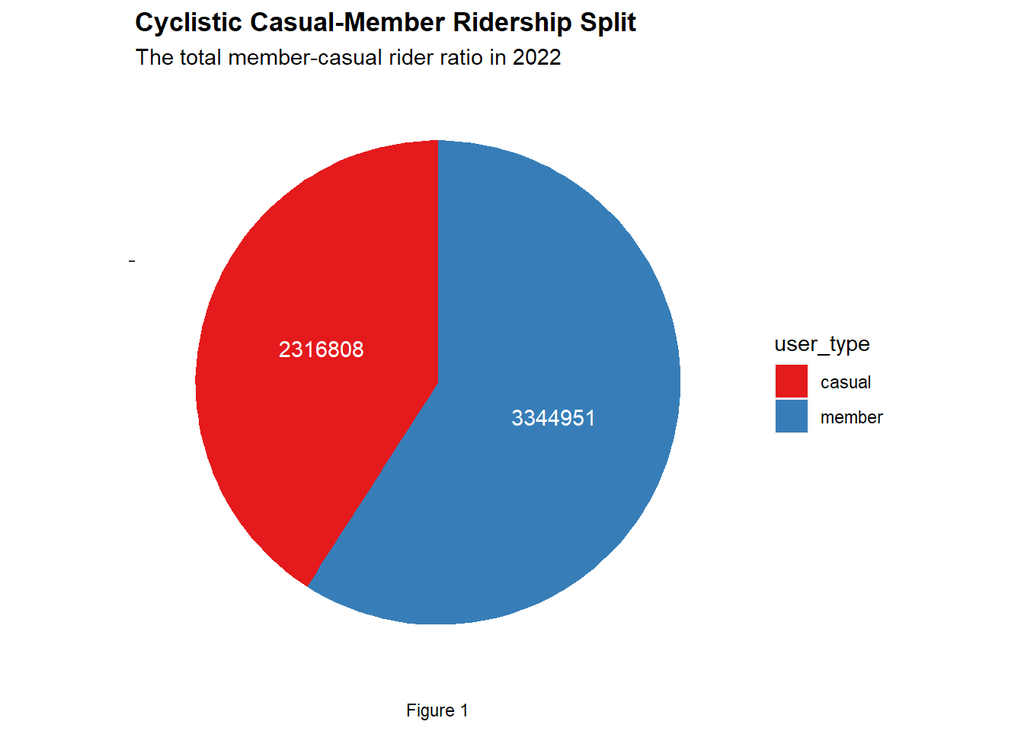

```r
# Pie charts in R a bit tricky, you need to create a bar chart then turn it around on it's y-axis
# to make it a pie chart

bar_plot <- trim_df %>%
  group_by(user_type) %>%
    summarise(number_of_users = n()) %>%
      ggplot(aes(x="", y = number_of_users, fill=user_type))+
        geom_bar(width = 1, stat = "identity") + # the rest of the code is to make the pie chart minimal and tidy
        labs(title = "Cyclistic Casual-Member Ridership Split",
             subtitle = "The total member-casual rider ratio in 2022",
              caption = "Figure 1") +
                geom_text(aes(label = number_of_users), position = position_stack(vjust = 0.5), color = "white") +
                theme(axis.text.x = element_blank(),
                      axis.title.x = element_blank(),
                      axis.text.y = element_blank(),
                      axis.title.y = element_blank(),
                      panel.background = element_rect(fill = 'white'),
                      panel.grid.major = element_blank(),
                      panel.grid.minor = element_blank(),
                      plot.caption = element_text(hjust = 0.5),
                      plot.title = element_text(face = "bold")) +
                      scale_fill_brewer(palette = "Set1")


# here we curl the bar plot in on itself to make a pie chart
pie <- bar_plot + coord_polar("y", start=0)
pie
```

```r
# save chart as jpg
ggsave("fig_1_cas_mem_pie.jpg")
```

**Ridereship Split**

There were a total of 5,661,759 bike hires in 2022, of which there were 18% more member riders than casual riders.

We break the figures down to view the monthly ridership:

```r
# first we shall put the months column in order

trim_df$month <- ordered(trim_df$month, levels=c("Jan", "Feb", "Mar", "Apr", "May", "Jun", "Jul", "Aug", "Sep", "Oct", "Nov", "Dec"))
```

```r
# The figures for the monthly ridership between members and causal riders

monthly_ridership <- trim_df %>%
  group_by(user_type, month) %>%                                     # groups by user_type and month
  summarise(number_of_hires = n(),                                   # calculates the number of rides
  Percentage_Split = round(100 * n()/nrow(.), digits = 2)) %>%       # calculates the %
  arrange(month, number_of_hires)                                      # sorts data


monthly_ridership
```

```
# A tibble: 24 × 4
# Groups:   user_type [2]
   user_type month number_of_hires Percentage_Split
   <chr>     <ord>           <int>            <dbl>
 1 casual    Jan             18463             0.33
 2 member    Jan             85221             1.51
 3 casual    Feb             21361             0.38
 4 member    Feb             94171             1.66
 5 casual    Mar             89642             1.58
 6 member    Mar            194132             3.43
 7 casual    Apr            126121             2.23
 8 member    Apr            244811             4.32
 9 casual    May            279764             4.94
10 member    May            354371             6.26
# … with 14 more rows
```

now we plot the data:

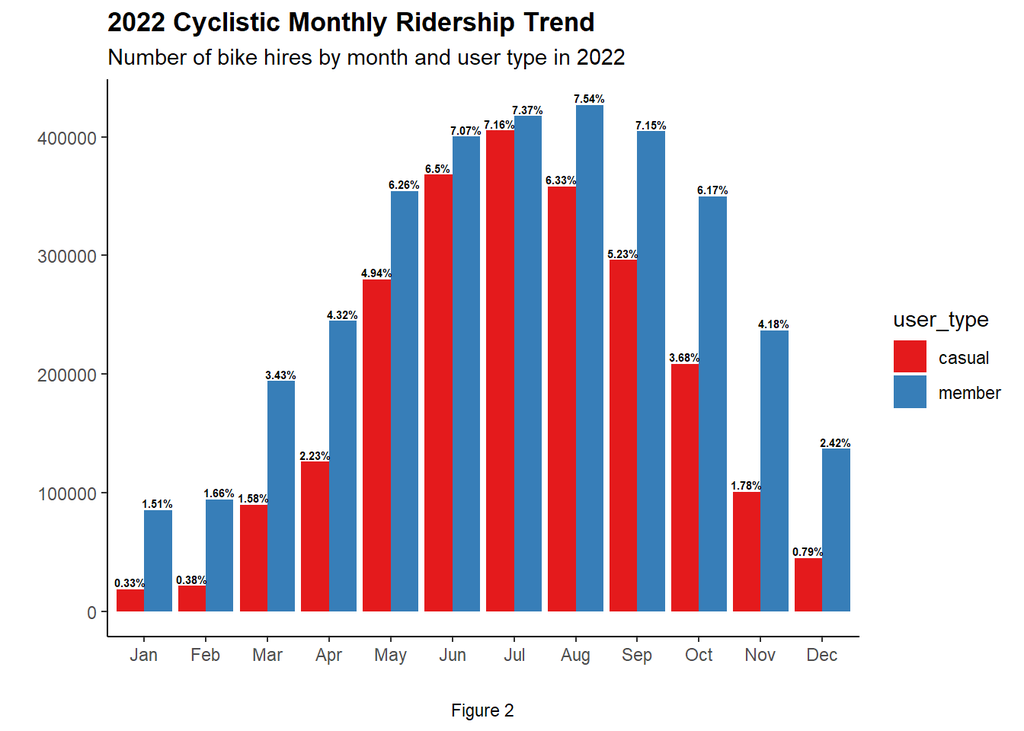

```r
options(scipen=999) # switch off scientific number format

monthly_ridership %>%
    group_by(month) %>%
    ggplot(aes(x=month, y=number_of_hires,  fill = user_type)) +
    geom_bar(position = "dodge",  stat="identity") +
    #geom_text(aes(label=paste0(Percentage_Split,"%")),nudge_y=25,colour = "black", size = 2) +
    geom_text(aes(label=paste0(Percentage_Split,"%")), position=position_dodge(width=0.9), vjust=-0.30, size = 2, fontface = "bold") +
    #geom_text(aes(label=number_of_hires), position=position_dodge(width=0.9), vjust=-0.25, size = 3, angle=45) +
    theme_classic() +
          labs(title = "2022 Cyclistic Monthly Ridership Trend",
             subtitle = "Number of bike hires by month and user type in 2022",
              x = "",
              y = "",
              caption = "Figure 2") +
              theme(plot.caption = element_text(hjust = 0.5),
                    plot.title = element_text(face = "bold")) +
              scale_fill_brewer(palette = "Set1")
```

```r
  ggsave("fig_2_monthly_ridership_cas_mem_bar.jpg")
```

```r
# highest performing month

trim_df %>%
  group_by(user_type, month) %>%         # groups by user_type and weekday
  summarise(number_of_hires = n(),        # calculates the number of rides
      Percentage_Split = round(100 * n()/nrow(.), digits = 2)) %>%  # % split
        arrange(-number_of_hires)              # sorts data
```

```
# A tibble: 24 × 4
# Groups:   user_type [2]
   user_type month number_of_hires Percentage_Split
   <chr>     <ord>           <int>            <dbl>
 1 member    Aug            426913             7.54
 2 member    Jul            417346             7.37
 3 casual    Jul            405179             7.16
 4 member    Sep            404544             7.15
 5 member    Jun            400055             7.07
 6 casual    Jun            368082             6.5
 7 casual    Aug            358161             6.33
 8 member    May            354371             6.26
 9 member    Oct            349595             6.17
10 casual    Sep            296074             5.23
# … with 14 more rows
```

If we examine the colder months of Nov, Dec, Jan, Feb and Mar and compare the with the hotter months:

```r
# Colder months

cold_months <- c("Jan", "Feb", "Mar", "Nov", "Dec")

trim_df %>%
    filter(month %in% cold_months) %>%
      group_by(user_type) %>%                                                    # groups by user_type
        summarise(number_of_hires = n(),                                            # calculates the number of rides
          Percentage_Split = round(100 * n()/nrow(trim_df), digits = 2)) %>%      # % split
            arrange(-number_of_hires)
```

```
# A tibble: 2 × 3
  user_type number_of_hires Percentage_Split
  <chr>               <int>            <dbl>
1 member             747316            13.2
2 casual             274816             4.85
```

```r
# hotter months

hot_months <- c("Apr", "May", "Jun", "Jul", "Aug", "Sep", "Oct")

trim_df %>%
    filter(month %in% hot_months) %>%
      group_by(user_type) %>%                                                    # groups by user_type
        summarise(number_of_hires = n(),                                            # calculates the number of rides
          Percentage_Split = round(100 * n()/nrow(trim_df), digits = 2)) %>%      # % split
            arrange(-number_of_hires)
```

```
# A tibble: 2 × 3
  user_type number_of_hires Percentage_Split
  <chr>               <int>            <dbl>
1 member            2597635             45.9
2 casual            2041992             36.1
```

A line graph will better demonstrate the ridership trend between the two groups.

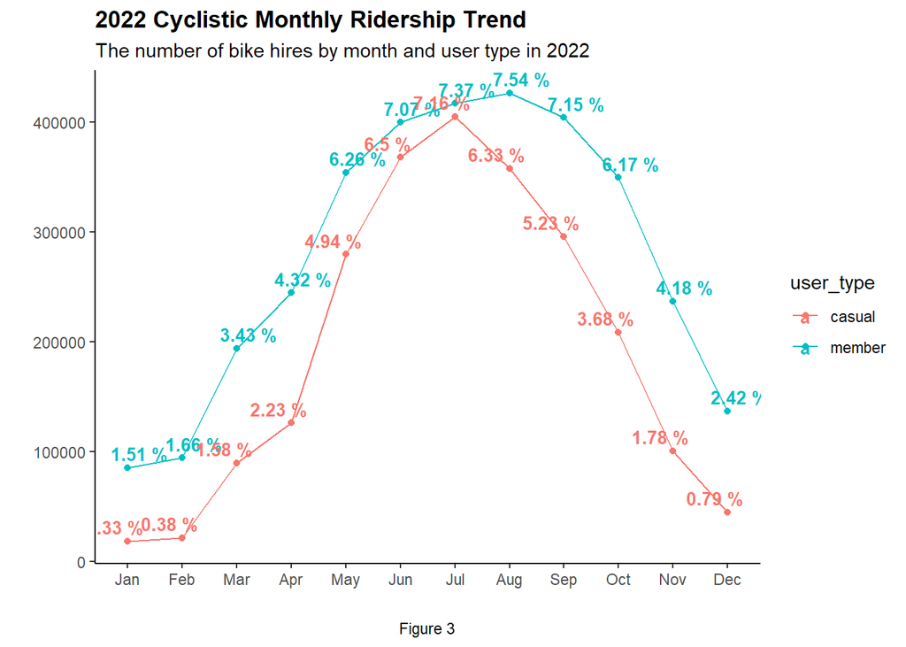

```r
options(scipen=999) # switch off scientific number format


monthly_ridership %>%
    group_by(month) %>%
    ggplot(aes(x=month, y=number_of_hires, colour = user_type)) +
    geom_point() +
    geom_line(aes(group = user_type)) +
    geom_text(aes(label=paste0(Percentage_Split," %")), position=position_dodge(width=0.9), vjust=-0.50, size = 3.5, fontface = "bold") +
    theme_classic() +
          labs(title = "2022 Cyclistic Monthly Ridership Trend",
             subtitle = "The number of bike hires by month and user type in 2022",
              x = "",
              y = "",
              caption = "Figure 3") +
              theme(plot.caption = element_text(hjust = 0.5),
                    plot.title = element_text(face = "bold")) +
              scale_fill_brewer(palette = "Set1")
```

```r
ggsave("fig_3_monthly_ridership_trend.jpg")
```

**Monthly Ridership stats:**

Monthly ridership followed a seasonal trend:

Hotter months : Apr - Oct

45.88 % membership riders 36.07 % casual riders

Colder months : Nov - Dec, Jan - Mar

Member ridership remains above casual riders for each month

We shall break the numbers down further and examine the daily average ridership between groups to see which days are the busiest

```r
# hire performance by day

weekday_ridership <- trim_df %>%
  group_by(user_type, weekday) %>%                               # groups by user_type and weekday
  summarise(number_of_hires = n(),                                 # calculates the number of rides
  Percentage_Split = round(100 * n()/nrow(.), digits = 2)) %>%   # % split
  arrange(-number_of_hires)                                      # sorts data from highest to lowest

weekday_ridership
```

```
# A tibble: 14 × 4
# Groups:   user_type [2]
   user_type weekday number_of_hires Percentage_Split
   <chr>     <ord>             <int>            <dbl>
 1 member    Thu              532154             9.4
 2 member    Wed              523770             9.25
 3 member    Tue              518507             9.16
 4 member    Mon              473249             8.36
 5 casual    Sat              472082             8.34
 6 member    Fri              466985             8.25
 7 member    Sat              443169             7.83
 8 casual    Sun              388011             6.85
 9 member    Sun              387117             6.84
10 casual    Fri              333938             5.9
11 casual    Thu              308713             5.45
12 casual    Mon              277054             4.89
13 casual    Wed              273823             4.84
14 casual    Tue              263187             4.65
```

Let’s plot it out, but before we do, let’s arrange the data into the proper weekday order

```r
# Arrange data in weekday order

trim_df$weekday <- ordered(trim_df$weekday, levels=c("Sun", "Mon", "Tue", "Wed", "Thu", "Fri", "Sat"))
```

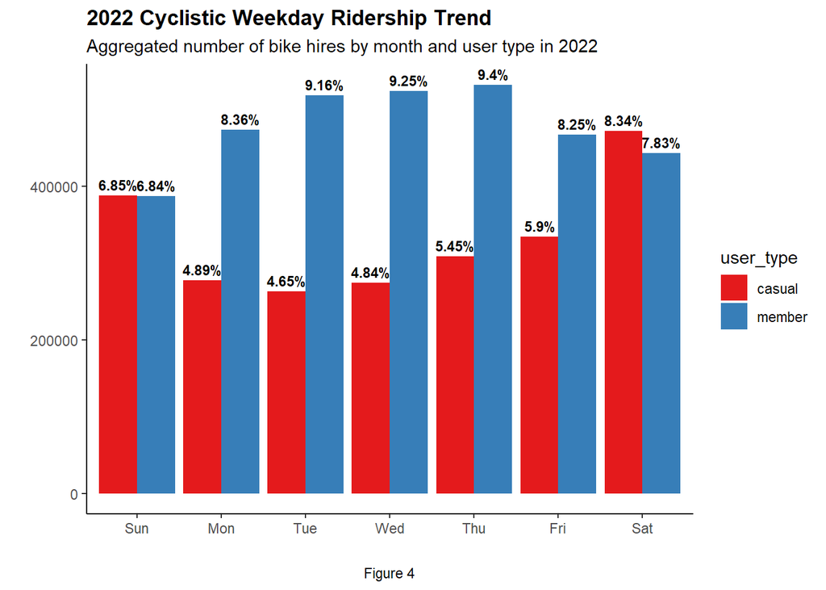

```r
options(scipen=999) # remove scientific numbering

weekday_ridership %>%
    group_by(weekday) %>%
    ggplot(aes(x=weekday, y=number_of_hires, fill = user_type)) +
    geom_bar(position = "dodge", stat="identity") +
    geom_text(aes(label=paste0(Percentage_Split,"%")), position=position_dodge(width=0.9), vjust=-0.50, size = 3, fontface = "bold") +
    theme_classic() +
          labs(title = "2022 Cyclistic Weekday Ridership Trend",
             subtitle = "Aggregated number of bike hires by month and user type in 2022",
              x = "",
              y = "",
              caption = "Figure 4") +
          theme(plot.caption = element_text(hjust = 0.5),
          plot.title = element_text(face = "bold")) +
          scale_fill_brewer(palette = "Set1")
```

```r
ggsave("fig_4_weekday_ridership_bar.jpg")
```

```r
# weekend ridership

weekend_days <- c("Sat", "Sun")

trim_df %>%
    filter(weekday %in% weekend_days) %>%
      group_by(user_type) %>%                                                    # groups by user_type
        summarise(number_of_hires = n(),                                            # calculates the number of rides
          Percentage_Split = round(100 * n()/nrow(trim_df), digits = 2)) %>%      # % split
            arrange(-number_of_hires)
```

```
# A tibble: 2 × 3
  user_type number_of_hires Percentage_Split
  <chr>               <int>            <dbl>
1 casual             860093             15.2
2 member             830286             14.7
```

```r
# work day ridership

week_days <- c("Mon", "Tue", "Wed","Thu", "Fri")

trim_df %>%
    filter(weekday %in% week_days) %>%
      group_by(user_type) %>%                                                    # groups by user_type
        summarise(number_of_hires = n(),                                            # calculates the number of rides
          Percentage_Split = round(100 * n()/nrow(trim_df), digits = 2)) %>%      # % split
            arrange(-number_of_hires)
```

```
# A tibble: 2 × 3
  user_type number_of_hires Percentage_Split
  <chr>               <int>            <dbl>
1 member            2514665             44.4
2 casual            1456715             25.7
```

**Ridership Analysis Summary**

**Work week : Mon - Fri showed around 19% more member users than casual** 44.41 % membership riders 25.73 % casual riders

**Maximum number of hires** Casual - 472,082 on Saturday (8% of total) Member - 532,154 on Thursday (9% of total)

**Lowest number of hires** Casual - 263,187 on Tuesday (5% of total) Member - 387,117 on Sunday (7% of total)

Let us break the ridership figures down further to see which hours of the day see the highest level of hires between the two groups

```r
# The time of day when bikes are taken out

hourly_ridership <- trim_df %>%
  group_by(user_type, start_hour) %>%                           # groups by user_type and starting hour
  summarise(number_of_hires = n(),                              # calculates the number of rides
  Percentage_Split = round(100 * n()/nrow(.), digits = 2)) %>%  # % split
  arrange(-number_of_hires)                                     # sorts data

hourly_ridership
```

```
# A tibble: 48 × 4
# Groups:   user_type [2]
   user_type start_hour number_of_hires Percentage_Split
   <chr>          <int>           <int>            <dbl>
 1 member            17          349355             6.17
 2 member            16          291722             5.15
 3 member            18          284565             5.03
 4 member            15          221528             3.91
 5 casual            17          219754             3.88
 6 member            19          206299             3.64
 7 member             8          204502             3.61
 8 casual            16          197300             3.48
 9 casual            18          197105             3.48
10 member            12          187454             3.31
# … with 38 more rows
```

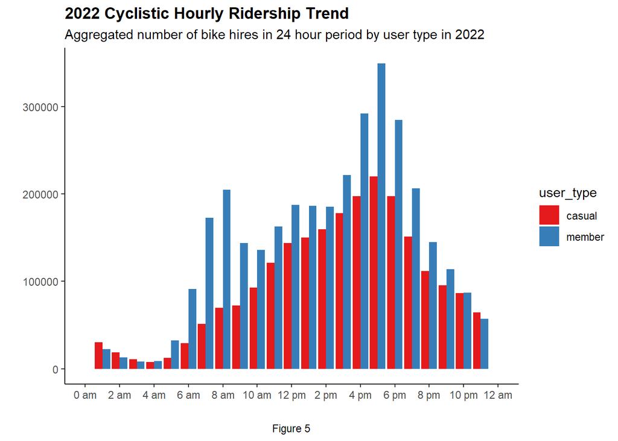

```r
options(scipen=999)   # remove scientific number notation

hourly_ridership %>%
    group_by(start_hour) %>%
    ggplot(aes(x=start_hour, y= number_of_hires, fill = user_type)) +
    geom_bar(position = "dodge", stat = "identity") +
    scale_x_continuous(limits=c(0,24),
                     breaks=0:12*2,
                     labels=c(paste(0:5*2,"am"),
                              "12 pm",
                              paste(7:11*2-12,"pm"),
                              "12 am")) +
   # geom_text(aes(label=paste0(Percentage_Split,"%")), position=position_dodge(width=0.9), hjust = -0.0, vjust=0.50, size = 3, fontface = "bold", angle=90) +
   theme_classic() +
          labs(title = "2022 Cyclistic Hourly Ridership Trend",
             subtitle = "Aggregated number of bike hires in 24 hour period by user type in 2022",
              x = "",
              y = "",
              caption = "Figure 5") +
          theme(plot.caption = element_text(hjust = 0.5),
          plot.title = element_text(face = "bold")) +
          scale_fill_brewer(palette = "Set1")
```

```r
ggsave("fig_5_hourly_ridership_bar.jpg")
```

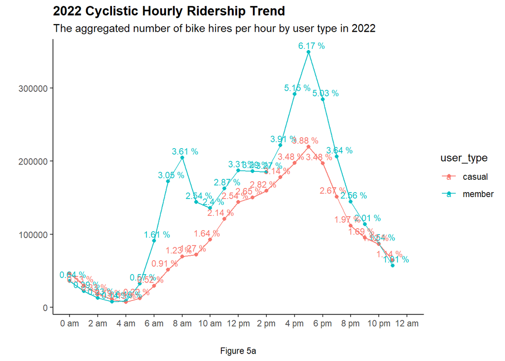

```r
options(scipen=999) # switch off scientific number format


hourly_ridership %>%
    group_by(start_hour) %>%
    ggplot(aes(x=start_hour, y= number_of_hires, colour = user_type)) +
    scale_x_continuous(limits=c(0,24),
                        breaks=0:12*2,
                        labels=c(paste(0:5*2,"am"),
                              "12 pm",
                              paste(7:11*2-12,"pm"),
                              "12 am")) +
    geom_point() +
    geom_line(aes(group = user_type)) +
    geom_text(aes(label=paste0(Percentage_Split," %")), position=position_dodge(width=0.9), vjust=-0.50, size = 3.0) +
    theme_classic() +
          labs(title = "2022 Cyclistic Hourly Ridership Trend",
             subtitle = "The aggregated number of bike hires per hour by user type in 2022",
              x = "",
              y = "",
              caption = "Figure 5a") +
              theme(plot.caption = element_text(hjust = 0.5),
                    plot.title = element_text(face = "bold")) +
              scale_fill_brewer(palette = "Set1")
```

```r
ggsave("fig_5a_hourly_ridership_trend.jpg")
```

**Commuter Trend Analysis**

Let us examine the percentage of riders that make the commute, i.e. Mon-Fri 7am-8am and 5pm-7pm

```r
work_days <- c("Mon", "Tue", "Wed", "Thu", "Fri")
peak_hours <- c(7, 8, 17, 18, 19 )

trim_df %>%
    filter(weekday %in% work_days & start_hour %in% peak_hours ) %>%
        summarise(number_of_hires = n(),                                            # calculates the number of rides
          Percentage_Split = round(100 * n()/nrow(trim_df), digits = 2)) %>%      # % split
            arrange(-number_of_hires)                                             # sorts data
```

```
# A tibble: 1,509,621 × 2
   number_of_hires Percentage_Split
             <int>            <dbl>
 1               1                0
 2               1                0
 3               1                0
 4               1                0
 5               1                0
 6               1                0
 7               1                0
 8               1                0
 9               1                0
10               1                0
# … with 1,509,611 more rows
```

```r
work_days <- c("Mon", "Tue", "Wed", "Thu", "Fri")
peak_hours <- c(7, 8, 17, 18, 19 )

trim_df %>%
    filter(weekday %in% work_days & start_hour %in% peak_hours ) %>%
      group_by(user_type) %>%                                                    # groups by user_type and starting hour
        summarise(number_of_hires = n(),                                            # calculates the number of rides
          Percentage_Split = round(100 * n()/nrow(trim_df), digits = 2)) %>%      # % split
            arrange(-number_of_hires)                                             # sorts data
```

```
# A tibble: 2 × 3
  user_type number_of_hires Percentage_Split
  <chr>               <int>            <dbl>
1 member            1011756            17.9
2 casual             497865             8.79
```

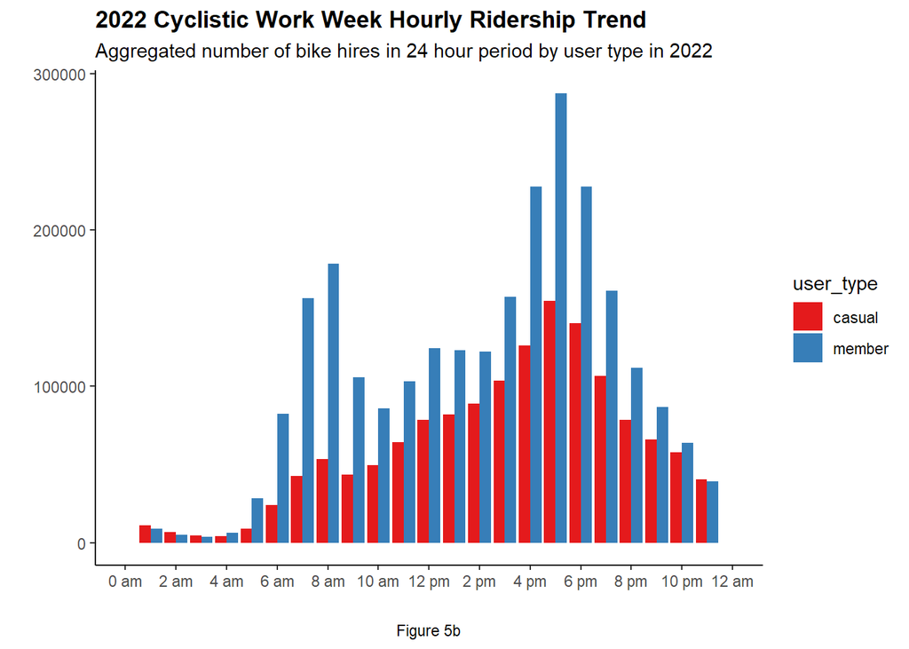

```r
options(scipen=999)   # remove scientific number notation

work_days <- c("Mon", "Tue", "Wed", "Thu", "Fri")

work_week <- trim_df %>%
    filter(weekday %in% work_days) %>%
      group_by(user_type, start_hour) %>%                                                    # groups by user_type and starting hour
        summarise(number_of_hires = n(),                                            # calculates the number of rides
          Percentage_Split = round(100 * n()/nrow(trim_df), digits = 2)) %>%      # % split
            arrange(-number_of_hires)                                             # sorts data


work_week %>%
    group_by(start_hour) %>%
    ggplot(aes(x=start_hour, y= number_of_hires, fill = user_type)) +
    geom_bar(position = "dodge", stat = "identity") +
    scale_x_continuous(limits=c(0,24),
                     breaks=0:12*2,
                     labels=c(paste(0:5*2,"am"),
                              "12 pm",
                              paste(7:11*2-12,"pm"),
                              "12 am")) +
   # geom_text(aes(label=paste0(Percentage_Split,"%")), position=position_dodge(width=0.9), hjust = -0.0, vjust=0.50, size = 3, fontface = "bold", angle=90) +
   theme_classic() +
          labs(title = "2022 Cyclistic Work Week Hourly Ridership Trend",
             subtitle = "Aggregated number of bike hires in 24 hour period by user type in 2022",
              x = "",
              y = "",
              caption = "Figure 5b") +
          theme(plot.caption = element_text(hjust = 0.5),
          plot.title = element_text(face = "bold")) +
          scale_fill_brewer(palette = "Set1")
```

```r
ggsave("fig_5b_work_week_hourly_ridership_bar.jpg")
```

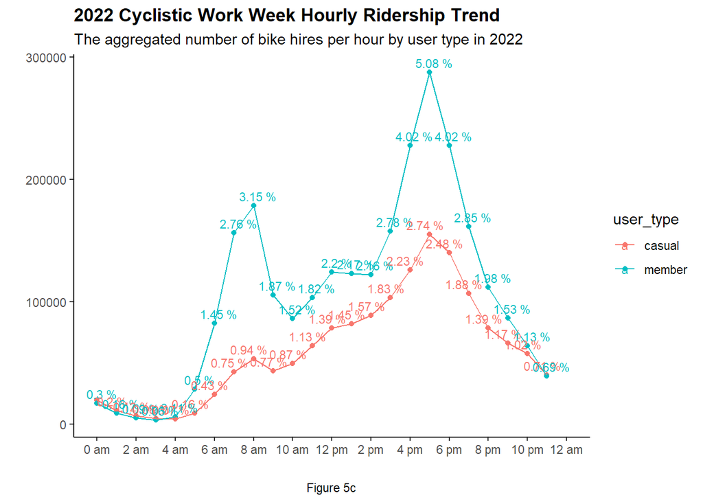

```r
options(scipen=999) # switch off scientific number format


work_week %>%
    group_by(start_hour) %>%
    ggplot(aes(x=start_hour, y= number_of_hires, colour = user_type)) +
    scale_x_continuous(limits=c(0,24),
                        breaks=0:12*2,
                        labels=c(paste(0:5*2,"am"),
                              "12 pm",
                              paste(7:11*2-12,"pm"),
                              "12 am")) +
    geom_point() +
    geom_line(aes(group = user_type)) +
    geom_text(aes(label=paste0(Percentage_Split," %")), position=position_dodge(width=0.9), vjust=-0.50, size = 3.0) +
    theme_classic() +
          labs(title = "2022 Cyclistic Work Week Hourly Ridership Trend",
             subtitle = "The aggregated number of bike hires per hour by user type in 2022",
              x = "",
              y = "",
              caption = "Figure 5c") +
              theme(plot.caption = element_text(hjust = 0.5),
                    plot.title = element_text(face = "bold")) +
              scale_fill_brewer(palette = "Set1")
```

```r
 ggsave("fig_5c_work_week_hourly_ridership_trend.jpg")
```

**Commuter Trend Analysis Summary**

The percentage of riders (both member and casual) that make the daily commute in 2022 is 26.66 % (1,509,621 riders).

The membership riders that commute make up 17.87 % (1,011,756) whereas the casual riders 8.79% (497,865) in 2022

We can view the hourly commuting ridership (Mon-Fri) on a graph

You can see from figure 5c that there two peaks in hiring for membership rides, namely 7-8 am and 4-6 pm, these can be interpreted as the commuting hours.

When compared to casual riders, they have a peak between 4-6pm which suggests that they may be hire bikes for their home commute.

This segment of casual riders use their bikes repeatedly, which makes them a good marketing candidate for converting over to member riders.

**Weekend Trend Analysis**

We shall examine how the rider groups use their bikes over the weekend.

We can also view the weekend hourly breakdown

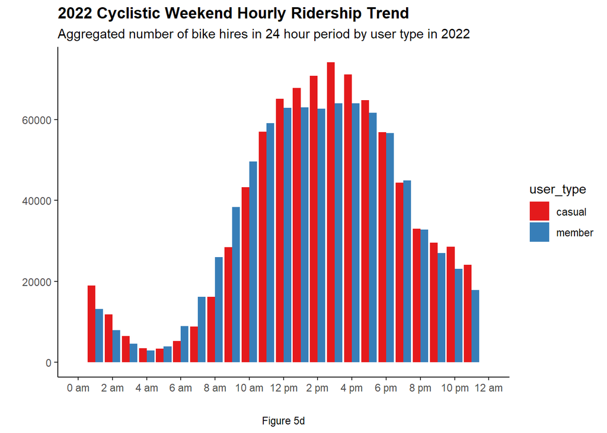

```r
options(scipen=999)   # remove scientific number notation
weekend_days <- c("Sat", "Sun")

weekend <- trim_df %>%
    filter(weekday %in% weekend_days) %>%
      group_by(user_type, start_hour) %>%                                                    # groups by user_type and starting hour
        summarise(number_of_hires = n(),                                            # calculates the number of rides
          Percentage_Split = round(100 * n()/nrow(trim_df), digits = 2)) %>%      # % split
            arrange(-number_of_hires)                                             # sorts data


weekend %>%
    group_by(start_hour) %>%
    ggplot(aes(x=start_hour, y= number_of_hires, fill = user_type)) +
    geom_bar(position = "dodge", stat = "identity") +
    scale_x_continuous(limits=c(0,24),
                     breaks=0:12*2,
                     labels=c(paste(0:5*2,"am"),
                              "12 pm",
                              paste(7:11*2-12,"pm"),
                              "12 am")) +
   # geom_text(aes(label=paste0(Percentage_Split,"%")), position=position_dodge(width=0.9), hjust = -0.0, vjust=0.50, size = 3, fontface = "bold", angle=90) +
   theme_classic() +
          labs(title = "2022 Cyclistic Weekend Hourly Ridership Trend",
             subtitle = "Aggregated number of bike hires in 24 hour period by user type in 2022",
              x = "",
              y = "",
              caption = "Figure 5d") +
          theme(plot.caption = element_text(hjust = 0.5),
          plot.title = element_text(face = "bold")) +
          scale_fill_brewer(palette = "Set1")
```

```r
ggsave("fig_5d_weekend_hourly_ridership_bar.jpg")
```

```r
# Calculate the percentage of weekend hires for both groups

weekend_ridership <- trim_df %>%
    filter(weekday %in% weekend_days) %>%
        summarise(number_of_hires = n(),                                            # calculates the number of rides
          Percentage_Split = round(100 * n()/nrow(trim_df), digits = 2)) %>%      # % split
            arrange(-number_of_hires)                                             # sorts data

weekend_ridership
```

```
# A tibble: 1,690,379 × 2
   number_of_hires Percentage_Split
             <int>            <dbl>
 1               1                0
 2               1                0
 3               1                0
 4               1                0
 5               1                0
 6               1                0
 7               1                0
 8               1                0
 9               1                0
10               1                0
# … with 1,690,369 more rows
```

We can examine the trend in weekend hires by hour

[figure not shown]

```r
options(scipen=999) # switch off scientific number format


weekend %>%
    group_by(start_hour) %>%
    ggplot(aes(x=start_hour, y= number_of_hires, colour = user_type)) +
    scale_x_continuous(limits=c(0,24),
                        breaks=0:12*2,
                        labels=c(paste(0:5*2,"am"),
                              "12 pm",
                              paste(7:11*2-12,"pm"),
                              "12 am")) +
    geom_point() +
    geom_line(aes(group = user_type)) +
    geom_text(aes(label=paste0(Percentage_Split," %")), position=position_dodge(width=0.9), vjust=-0.50, size = 3.0) +
    theme_classic() +
          labs(title = "2022 Cyclistic Weekend Hourly Ridership Trend",
             subtitle = "The aggregated number of bike hires per hour by user type in 2022",
              x = "",
              y = "",
              caption = "Figure 5c") +
              theme(plot.caption = element_text(hjust = 0.5),
                    plot.title = element_text(face = "bold")) +
              scale_fill_brewer(palette = "Set1")
```

```r
 ggsave("fig_5e_weekend_hourly_ridership_trend.jpg")
```

```r
trim_df %>%
    filter(weekday %in% weekend_days) %>%
      group_by(user_type) %>%
        summarise(number_of_hires = n(),                                            # calculates the number of rides
          Percentage_Split = round(100 * n()/nrow(trim_df), digits = 2)) %>%      # % split
            arrange(-number_of_hires)                                             # sorts data
```

```
# A tibble: 2 × 3
  user_type number_of_hires Percentage_Split
  <chr>               <int>            <dbl>
1 casual             860093             15.2
2 member             830286             14.7
```

```r
trim_df %>%
    filter(weekday %in% weekend_days) %>%
      group_by(user_type, weekday) %>%
        summarise(number_of_hires = n(),                                            # calculates the number of rides
          Percentage_Split = round(100 * n()/nrow(trim_df), digits = 2)) %>%      # % split
            arrange(-number_of_hires)                                             # sorts data
```

```
# A tibble: 4 × 4
# Groups:   user_type [2]
  user_type weekday number_of_hires Percentage_Split
  <chr>     <ord>             <int>            <dbl>
1 casual    Sat              472082             8.34
2 member    Sat              443169             7.83
3 casual    Sun              388011             6.85
4 member    Sun              387117             6.84
```

```r
tapply(hourly_ridership$number_of_hires, hourly_ridership$user_type, summary)
```

```
$casual
   Min. 1st Qu.  Median    Mean 3rd Qu.    Max.
   7567   42233   89542   96534  150288  219754

$member
   Min. 1st Qu.  Median    Mean 3rd Qu.    Max.
   8049   51733  144362  139373  191716  349355
```

**Weekend Trends Analysis Summary**

The aggregated weekend ridership stats:

Total weekend hires for 2022 : 29.86% (1,690,379 bike hires in total)

casual Sat 472,082 8.34 % member Sat 443,169 7.83 %

casual Sun 388,011 6.85 % member Sun 387,117 6.84 %

The data shows a balanced ridership during weekend hires. The peak hires for both is between 11am to 7pm which indicates both users may use their bikes for leisure during the weekend.

#### **Trip Duration Analysis**

Here we will break down the trip lengths into their various metrics to gain insights into rider usage patterns and compare them with each rider group.

1. Let us first examine the min, max, mean and median trip duration for the entire year both users combined

```r
trip_dur_summary <- trim_df %>%
    summarise(mean_dur_sec = mean(trip_dur_sec),
              median_dur_sec = median(trip_dur_sec),
              max_dur_sec = max(trip_dur_sec),
              min_dur_sec = min(trip_dur_sec))

trip_dur_summary
```

```
# A tibble: 5,661,759 × 4
   mean_dur_sec median_dur_sec max_dur_sec min_dur_sec
          <dbl>          <dbl>       <dbl>       <dbl>
 1          620            620         620         620
 2          921            921         921         921
 3         2709           2709        2709        2709
 4         1521           1521        1521        1521
 5         2756           2756        2756        2756
 6         1871           1871        1871        1871
 7         6232           6232        6232        6232
 8         1269           1269        1269        1269
 9         1624           1624        1624        1624
10         1235           1235        1235        1235
# … with 5,661,749 more rows
```

**2022 Trip Duration**

```r
summary(trim_df$trip_dur_sec)
```

```
     Min.   1st Qu.    Median      Mean   3rd Qu.      Max.
      0.0     349.0     616.0     979.8    1105.0 2061244.0
```

```r
trim_df %>%
  slice_max(trip_dur_sec)
```

```
# A tibble: 5,661,759 × 12
# Rowwise:
   user_type bike_…¹ route start_…² end_time trip_…³ start…⁴ weekday month  year
   <chr>     <chr>   <chr> <time>   <time>     <dbl>   <int> <ord>   <ord> <dbl>
 1 casual    docked… elst… 09:26:28 09:36:48     620       9 Sat     Jan    2022
 2 casual    docked… west… 10:40:40 10:56:01     921      10 Thu     Feb    2022
 3 casual    docked… clar… 21:13:48 21:58:57    2709      21 Thu     Feb    2022
 4 casual    docked… sher… 17:30:58 17:56:19    1521      17 Sat     Apr    2022
 5 casual    docked… mich… 13:56:37 14:42:33    2756      13 Tue     Apr    2022
 6 casual    docked… stre… 17:42:27 18:13:38    1871      17 Mon     Apr    2022
 7 casual    docked… clar… 15:54:48 17:38:40    6232      15 Thu     Apr    2022
 8 casual    docked… wood… 18:37:57 18:59:06    1269      18 Sat     Apr    2022
 9 casual    docked… dusa… 15:49:59 16:17:03    1624      15 Fri     Apr    2022
10 casual    docked… rush… 14:19:01 14:39:36    1235      14 Tue     Apr    2022
# … with 5,661,749 more rows, 2 more variables: date <date>, stn_dist_km <dbl>,
#   and abbreviated variable names ¹bike_type, ²start_time, ³trip_dur_sec,
#   ⁴start_hour
```

We can break the stats down by user type

```r
trim_df %>%
    group_by(user_type) %>%
    summarise(mean_dur_sec = mean(trip_dur_sec),
              median_dur_sec = median(trip_dur_sec),
              max_dur_sec = max(trip_dur_sec),
              min_dur_sec = min(trip_dur_sec))
```

```
# A tibble: 2 × 5
  user_type mean_dur_sec median_dur_sec max_dur_sec min_dur_sec
  <chr>            <dbl>          <dbl>       <dbl>       <dbl>
1 casual           1319.            778     2061244           0
2 member            745.            530       89996           0
```

we can break that down by month

```r
trip_dur_month_summary <- trim_df %>%
    group_by(month) %>%
    summarise(mean_dur_sec = mean(trip_dur_sec),
              median_dur_sec = median(trip_dur_sec),
              max_dur_sec = max(trip_dur_sec),
              min_dur_sec = min(trip_dur_sec))

trip_dur_month_summary
```

```
# A tibble: 12 × 5
   month mean_dur_sec median_dur_sec max_dur_sec min_dur_sec
   <ord>        <dbl>          <dbl>       <dbl>       <dbl>
 1 Jan           826.           472      1756266           0
 2 Feb           786.           482       654358           0
 3 Mar           970.           568      2061244           0
 4 Apr           926.           567       452758           0
 5 May          1114.           693       643378           0
 6 Jun          1099.           712       400372           0
 7 Jul          1097.           701      1922127           0
 8 Aug          1013.           657       290901           0
 9 Sep           944.           612        89995           0
10 Oct           847.           540.      494628           0
11 Nov           734.           483        89995           0
12 Dec           666.           447        89996           0
```

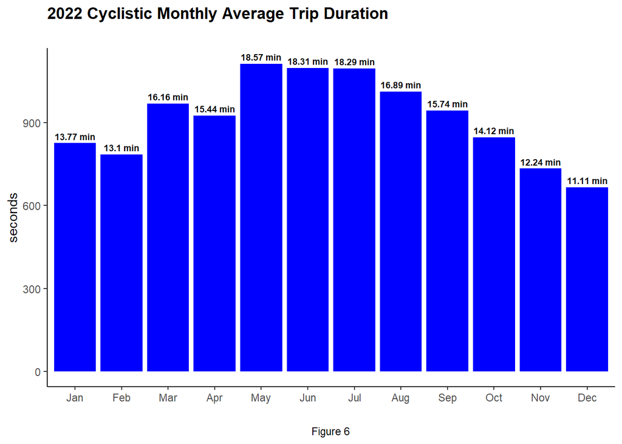

```r
trip_dur_month_summary %>%
    group_by(month) %>%
      ggplot(aes(x=month, y=mean_dur_sec)) +
      geom_col(fill=alpha("blue", 1.0)) +
      geom_text(aes(label=paste0(round(mean_dur_sec/60, digits = 2)," min")), position=position_dodge(width=0.9), vjust=-0.50, size = 2.5, fontface = "bold") +

      theme_classic() +
          labs(title = "2022 Cyclistic Monthly Average Trip Duration",
             subtitle = "",
              x = "",
              y = "seconds",
              caption = "Figure 6") +
          theme(plot.caption = element_text(hjust = 0.5),
          plot.title = element_text(face = "bold")) +
          scale_fill_brewer(palette = "Set1")
```

```r
ggsave("fig_6_monthly_avg_trip_dur.jpg")
```

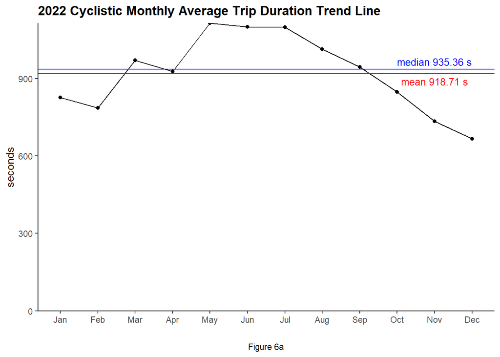

```r
options(scipen=999) # switch off scientific number format

cyclistic_2022_mean <- round(mean(trip_dur_month_summary$mean_dur_sec), digits = 2)
cyclistic_2022_median <- round(median(trip_dur_month_summary$mean_dur_sec), digits = 2)

mean_label <- paste("mean", as.character(cyclistic_2022_mean), "s")
median_label <- paste("median", as.character(cyclistic_2022_median), "s")


trip_dur_month_summary %>%
    group_by(month) %>%
    ggplot(aes(x=month, y=mean_dur_sec)) +
    scale_y_continuous(expand = c(0, 0), limits = c(0, NA)) +

    geom_point() +
    geom_line(aes(group=1)) +

    geom_hline(yintercept=cyclistic_2022_mean,color="red") +
    annotate("text", x="Nov", y=cyclistic_2022_mean - 30, label= mean_label, size=3.5, color="red") +

    geom_hline(yintercept=cyclistic_2022_median, color="blue") +
    annotate("text", x="Nov", y=cyclistic_2022_median + 30, label= median_label, size=3.5, color="blue") +

    theme_classic() +
          labs(title = "2022 Cyclistic Monthly Average Trip Duration Trend Line",
              x = "",
              y = "seconds",
              caption = "Figure 6a") +
              theme(plot.caption = element_text(hjust = 0.5),
                    plot.title = element_text(face = "bold")) +
              scale_fill_brewer(palette = "Set1")
```

```r
ggsave("fig_6a_monthly_avg_dur_trend_user.jpg")
```

**2022 Trip Duration Summary**

The data shows a tapering off trip duration during the winter months.

**Trip Duration Analysis by Rider**

We break the monthly average trip duration by user type:

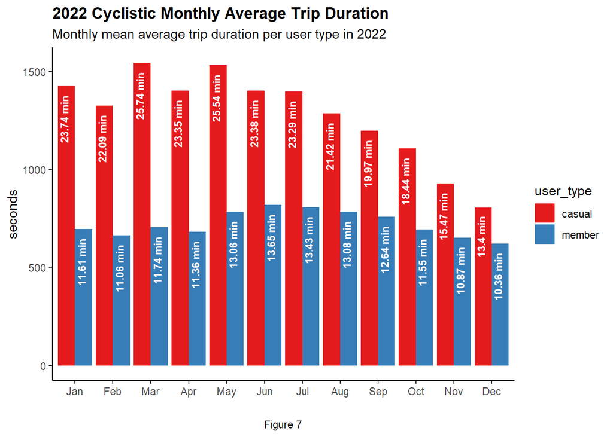

```r
dur_month_sum <- trim_df %>%
    group_by(month, user_type) %>%
    summarise(mean_dur_sec = mean(trip_dur_sec),
              median_dur_sec = median(trip_dur_sec),
              max_dur_sec = max(trip_dur_sec),
              min_dur_sec = min(trip_dur_sec))



dur_month_sum %>%
    group_by(month, user_type) %>%
      ggplot(aes(x=month, y=mean_dur_sec, fill = user_type)) +
      geom_col(position = "dodge") +
      # geom_point() +
      # geom_line(aes(group = user_type, colour = user_type)) +
      geom_text(aes(label=paste0(round(mean_dur_sec/60, digits = 2)," min")),        position=position_dodge(width=0.9), hjust=1.2, vjust=0.2, size = 3, fontface = "bold", angle=90, colour = "white") +
      theme_classic() +
          labs(title = "2022 Cyclistic Monthly Average Trip Duration",
             subtitle = "Monthly mean average trip duration per user type in 2022",
              x = "",
              y = "seconds",
              caption = "Figure 7") +
          theme(plot.caption = element_text(hjust = 0.5),
          plot.title = element_text(face = "bold")) +
          scale_fill_brewer(palette = "Set1")
```

```r
ggsave("fig_7_monthly_avg_dur_user.jpg")
```

Let us examine the trend line for the monthly average (mean) trip duration per user type

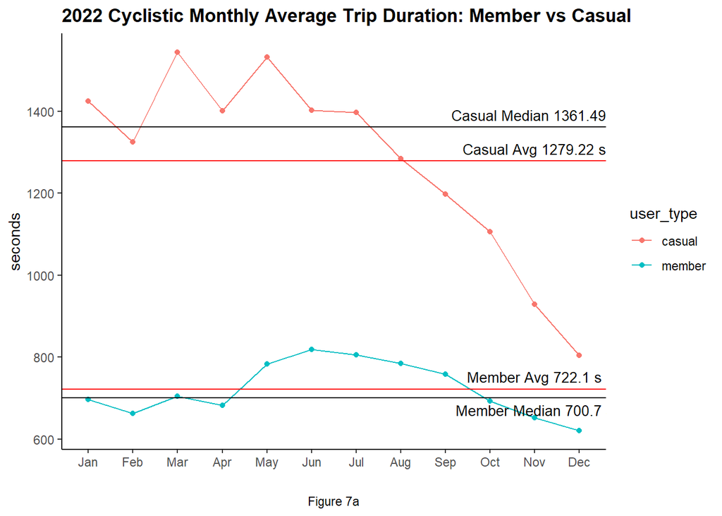

```r
options(scipen=999) # switch off scientific number format

# mean values calc

casual_mean <- round(mean(dur_month_sum$mean_dur_sec[dur_month_sum$user_type=="casual"]), digits = 2)
member_mean <- round(mean(dur_month_sum$mean_dur_sec[dur_month_sum$user_type=="member"]), digits = 2)

casual_mean_label <- paste("Casual Avg", as.character(casual_mean), "s")
member_mean_label <- paste("Member Avg", as.character(member_mean), "s")

# median value calc

casual_median <- round(median(dur_month_sum$mean_dur_sec[dur_month_sum$user_type=="casual"]), digits = 2)
member_median <- round(median(dur_month_sum$mean_dur_sec[dur_month_sum$user_type=="member"]), digits = 2)

casual_median_label <- paste("Casual Median", as.character(casual_median), "s")
member_median_label <- paste("Member Median", as.character(member_median), "s")

dur_month_sum %>%
    group_by(month) %>%
    ggplot(aes(x=month, y=mean_dur_sec, colour = user_type)) +
    geom_point() +
    geom_line(aes(group = user_type)) +

    # Mean values
    geom_hline(yintercept=casual_mean,color="red") +
    annotate("text", x="Nov", y=casual_mean + 30, label= casual_mean_label, size=3.5, color="black") +

    geom_hline(yintercept=member_mean,color="red") +
    annotate("text", x="Nov", y=member_mean + 30, label= member_mean_label, size=3.5, color="black") +

    # Median values

    geom_hline(yintercept=casual_median,color="black") +
    annotate("text", x="Nov", y=casual_median + 30, label= casual_median_label, size=3.5, color="black") +

    geom_hline(yintercept=member_median,color="black") +
    annotate("text", x="Nov", y=member_median - 30, label= member_median_label, size=3.5, color="black") +


      theme_classic() +
          labs(title = "2022 Cyclistic Monthly Average Trip Duration: Member vs Casual",
              x = "",
              y = "seconds",
              caption = "Figure 7a") +
              theme(plot.caption = element_text(hjust = 0.5),
                    plot.title = element_text(face = "bold")) +
              scale_fill_brewer(palette = "Set1")
```

```r
ggsave("fig_7a_monthly_avg_dur_trend_user.jpg")
```

Let us calculate the average for each user type then find the standard deviation

```r
dur_month_sum %>%
      group_by(user_type) %>%
        summarise(avg_dur_sec = mean(mean_dur_sec),
                  standard_deviation = sd(mean_dur_sec),
                  median_dur_sec = median(mean_dur_sec))
```

```
# A tibble: 2 × 4
  user_type avg_dur_sec standard_deviation median_dur_sec
  <chr>           <dbl>              <dbl>          <dbl>
1 casual          1279.              231.           1361.
2 member           722.               65.7           701.
```

**Monthly Trip Duration Summary**

Casual users have 77% longer trips than members.

Member users maintain a constant usage throughout the year showing marginal changes in hotter and colder months Conclusion : casual users use their bikes for leisure and member riders use their bikes for commuting**

**Weekday trip Duration Analysis**

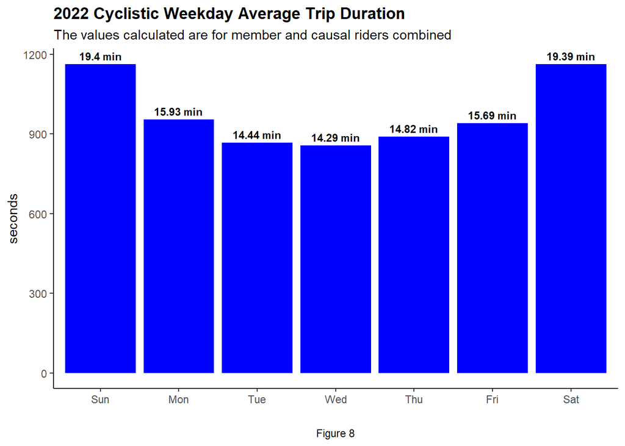

```r
trim_df %>%
    group_by(weekday) %>%
    summarise(mean_dur_sec = mean(trip_dur_sec)) %>%
      ggplot(aes(x=weekday, y=mean_dur_sec), fill=user_type) +
      geom_col(fill=alpha("blue", 1.0)) +
      geom_text(aes(label=paste0(round(mean_dur_sec/60, digits = 2)," min")), position=position_dodge(width=0.9), vjust=-0.50, size = 3, fontface = "bold") +
      theme_classic() +
          labs(title = "2022 Cyclistic Weekday Average Trip Duration",
             subtitle = "The values calculated are for member and causal riders combined",
              x = "",
              y = "seconds",
              caption = "Figure 8") +
          theme(plot.caption = element_text(hjust = 0.5),
          plot.title = element_text(face = "bold")) +
          scale_fill_brewer(palette = "Set1")
```

```r
ggsave("fig_8_daily_average_trip_dur.jpg")
```

Let us break down Fig.8 for both user groups.

```r
# arrange weekdays in order first

trim_df$weekday <- ordered(trim_df$weekday, levels=c("Sun", "Mon", "Tue", "Wed", "Thu", "Fri", "Sat"))
```

```r
weekday_avg_trip_dur <- trim_df %>%
  aggregate(trip_dur_sec ~ user_type + weekday, FUN = mean)

weekday_avg_trip_dur
```

```
   user_type weekday trip_dur_sec
1     casual     Sun    1505.6169
2     member     Sun     821.5547
3     casual     Mon    1357.7269
4     member     Mon     720.2955
5     casual     Tue    1177.9052
6     member     Tue     708.6599
7     casual     Wed    1140.0512
8     member     Wed     710.0717
9     casual     Thu    1180.4805
10    member     Thu     720.6420
11    casual     Fri    1231.8108
12    member     Fri     733.5506
13    casual     Sat    1478.7317
14    member     Sat     827.4870
```

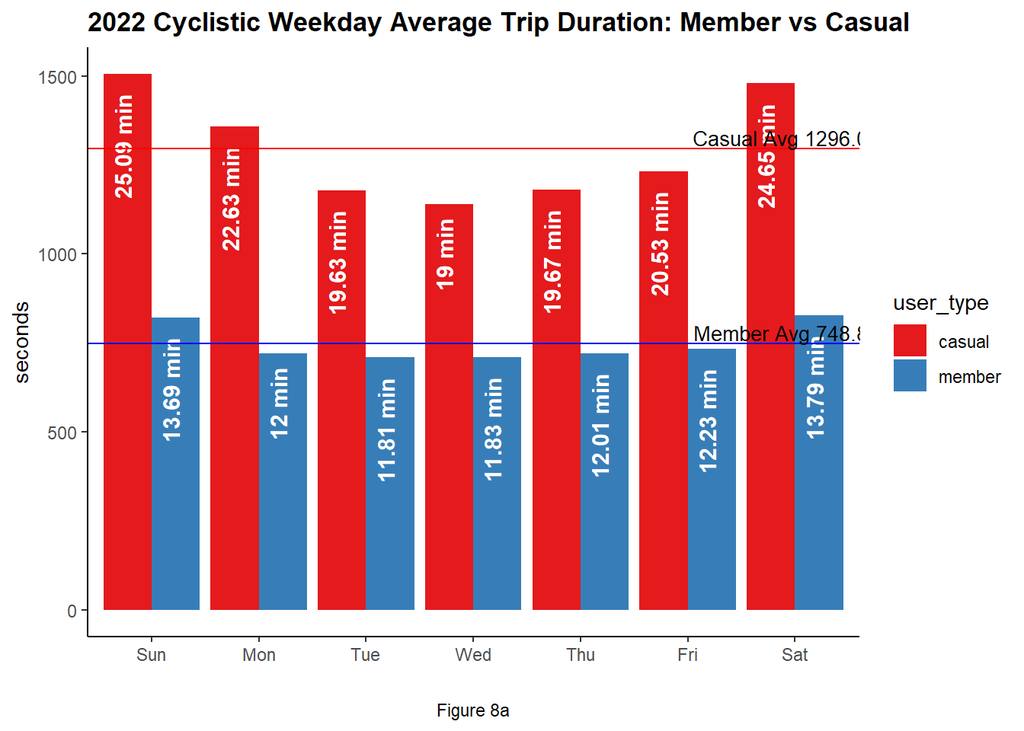

```r
options(scipen=999) # remove scientific numbering

casual_mean <- round(mean(weekday_avg_trip_dur$trip_dur_sec[weekday_avg_trip_dur$user_type=="casual"]), digits = 2)
member_mean <- round(mean(weekday_avg_trip_dur$trip_dur_sec[weekday_avg_trip_dur$user_type=="member"]), digits = 2)

casual_mean_label <- paste("Casual Avg", as.character(casual_mean), "s")
member_mean_label <- paste("Member Avg", as.character(member_mean), "s")

# plot graph with averages

weekday_avg_trip_dur %>%
    group_by(weekday) %>%
    ggplot(aes(x=weekday, y=trip_dur_sec, fill = user_type)) +
    geom_bar(position = "dodge", stat="identity") +
    geom_text(aes(label=paste0(round(trip_dur_sec/60, digits = 2)," min")),        position=position_dodge(width=0.9), hjust=1.2, vjust=0.2, size = 4, fontface = "bold", angle=90, colour = "white") +


      # Mean values
    geom_hline(yintercept=casual_mean,color="red") +
    annotate("text", x="Sat", y=casual_mean + 30, label= casual_mean_label, size=3.5, color="black") +

    geom_hline(yintercept=member_mean,color="blue") +
    annotate("text", x="Sat", y=member_mean + 30, label= member_mean_label, size=3.5, color="black") +

    theme_classic() +
          labs(title = "2022 Cyclistic Weekday Average Trip Duration: Member vs Casual",
              x = "",
              y = "seconds",
              caption = "Figure 8a") +
          theme(plot.caption = element_text(hjust = 0.5),
          plot.title = element_text(face = "bold")) +
          scale_fill_brewer(palette = "Set1")
```

```r
ggsave("fig_8a_daily_average_trip_dur_mem_cas.jpg")
```

**Weekday Trip Duration Analysis Summary**

In 2022, casual riders, on average, had 80% longer trip length than member riders during the weekends.

Average trip lengths for member riders remained approximately the same throughout the week when compared to causal riders

This supports the assumption that member riders are more commuter-centric and casual leisure-centric in the manner in which they use their bikes

#### **Bike Type Analysis**

Here we look at the user preference when it comes to bike types. Let’s start with overall usage for both groups.

```r
# Overall bike usage

bike_type_stats <- trim_df %>%
  group_by(bike_type) %>%
  summarise(number_of_users = n(),
            Percentage_Split = round(100 * n()/nrow(.), digits = 2))


bike_type_stats
```

```
# A tibble: 3 × 3
  bike_type     number_of_users Percentage_Split
  <chr>                   <int>            <dbl>
1 classic_bike          2597944            45.9
2 docked_bike            174858             3.09
3 electric_bike         2888957            51.0
```

Visualization of bike type usage on a pie chart

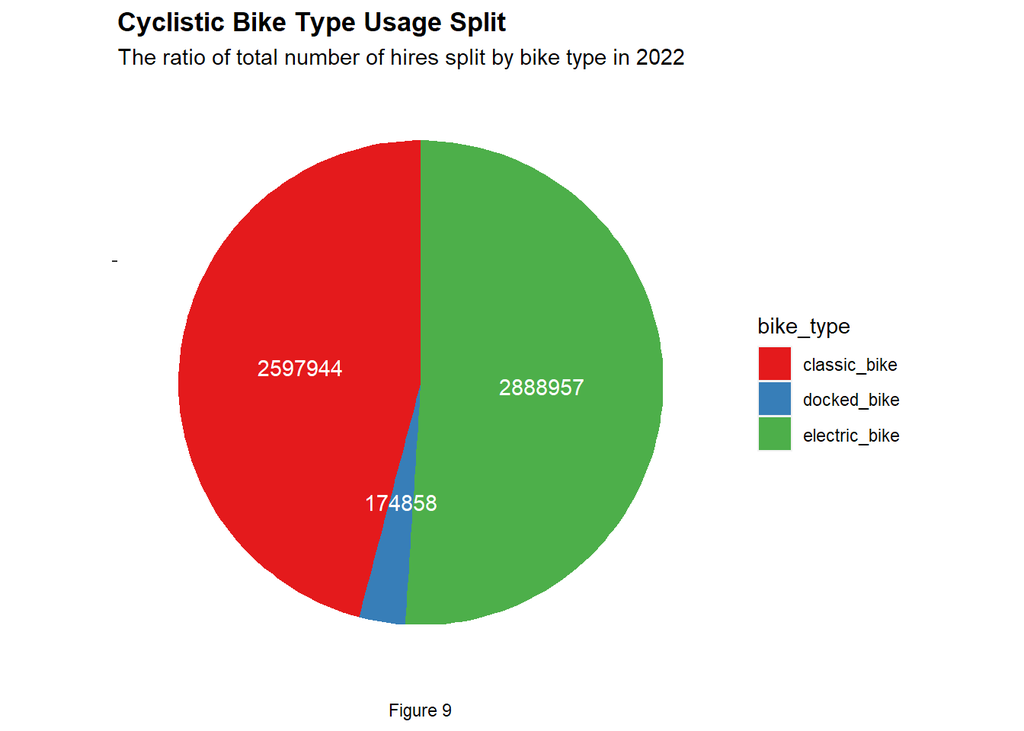

```r
# Pie charts in R a bit tricky, you need to create a bar chart then turn it around on it's y-axis
# to make it a pie chart

bar_plot <- bike_type_stats %>%
  group_by(bike_type) %>%
      ggplot(aes(x="", y = number_of_users, fill=bike_type))+
        geom_bar(width = 1, stat = "identity") + # the rest of the code is to make the pie chart minimal and tidy
        labs(title = "Cyclistic Bike Type Usage Split",
              subtitle = "The ratio of total number of hires split by bike type in 2022",
              caption = "Figure 9") +
                geom_text(aes(label = number_of_users), position = position_stack(vjust = 0.5), color = "white") +
                theme(axis.text.x = element_blank(),
                      axis.title.x = element_blank(),
                      axis.text.y = element_blank(),
                      axis.title.y = element_blank(),
                      panel.background = element_rect(fill = 'white'),
                      panel.grid.major = element_blank(),
                      panel.grid.minor = element_blank(),
                      plot.caption = element_text(hjust = 0.5),
                      plot.title = element_text(face = "bold")) +
                      scale_fill_brewer(palette = "Set1")


# here we curl the bar plot in on itself to make a pie chart
pie <- bar_plot + coord_polar("y", start=0)
pie
```

```r
ggsave("fig_9_bike_type_pie.jpg")
```

**Bike Type Summary**

Bike type preference from the total of 5,661,759 bike hires in 2022 were as follows:

45.89 % Classic bikes (2,597,944)  
51.03 % Electric bike (2,888,957)  
3.09 % Docked bike (174,858)

There was a balanced hireship between classic and electric bikes, whereas docked bikes had the least of the three types.

Let us now break this figure down by member/casual riders to see their preference.

```r
# Overall bike usage by rider type

bike_type_by_user <- trim_df %>%
  group_by(user_type, bike_type) %>%
  summarise(number_of_users = n(),
            Percentage_Split = round(100 * n()/nrow(.), digits = 2)) %>%
  arrange(user_type)

bike_type_by_user
```

```
# A tibble: 5 × 4
# Groups:   user_type [2]
  user_type bike_type     number_of_users Percentage_Split
  <chr>     <chr>                   <int>            <dbl>
1 casual    classic_bike           888890            15.7
2 casual    docked_bike            174858             3.09
3 casual    electric_bike         1253060            22.1
4 member    classic_bike          1709054            30.2
5 member    electric_bike         1635897            28.9
```

We now plot the results on a graph.

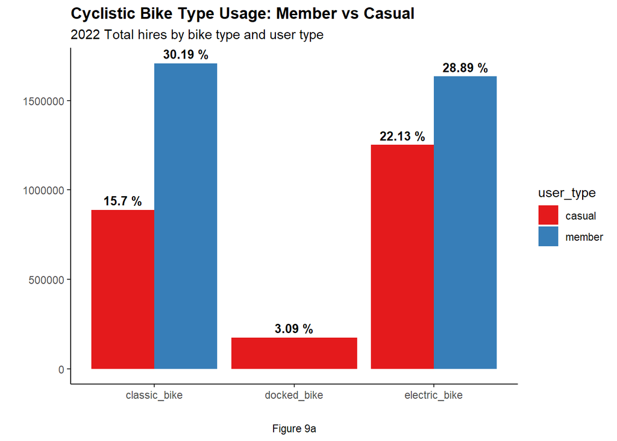

```r
# bike type usage trends in 2022

bike_type_by_user %>%
  group_by(user_type, bike_type) %>%
    arrange(user_type, bike_type)  %>%
      ggplot(aes(x = bike_type, y = number_of_users, fill = user_type)) +
      geom_col(position = "dodge") +
      geom_text(aes(label=paste0(Percentage_Split," %")), position=position_dodge(width=0.9), vjust=-0.50, size = 3.5, fontface = "bold") +
        theme_classic() +
          labs(title = "Cyclistic Bike Type Usage: Member vs Casual",
               subtitle = "2022 Total hires by bike type and user type",
               x = "",
               y = "",
               caption = "Figure 9a") +
          theme(plot.caption = element_text(hjust = 0.5),
          plot.title = element_text(face = "bold")) +
          scale_fill_brewer(palette = "Set1")
```

```r
ggsave("fig_9a_bike_type_split_pie.jpg")
```

We break the figures down for each month in 2022

First we order the months

```r
# we shall the order for the months column first

trim_df$month <- ordered(trim_df$month, levels=c("Jan", "Feb", "Mar", "Apr", "May", "Jun", "Jul", "Aug", "Sep", "Oct", "Nov", "Dec"))
```

We print out a table of the data

```r
# We check the bike hires per month grouped by bike type and user type.

bike_type_month_summary <- trim_df %>%
  group_by(month, bike_type) %>%
  summarise(number_of_hires = n(),
            Percentage_Split = round(100 * n()/nrow(.), digits = 2)) %>%
            arrange(-Percentage_Split)

bike_type_month_summary
```

```
# A tibble: 36 × 4
# Groups:   month [12]
   month bike_type     number_of_hires Percentage_Split
   <ord> <chr>                   <int>            <dbl>
 1 Jul   electric_bike          419254             7.41
 2 Aug   electric_bike          415545             7.34
 3 Jun   classic_bike           406033             7.17
 4 Sep   electric_bike          375363             6.63
 5 Jul   classic_bike           372672             6.58
 6 Aug   classic_bike           343641             6.07
 7 Oct   electric_bike          332508             5.87
 8 Jun   electric_bike          331892             5.86
 9 May   classic_bike           323613             5.72
10 Sep   classic_bike           305767             5.4
# … with 26 more rows
```

```r
# Monthly usage statistics by bike type

bike_type_month_summary %>%
  filter(bike_type=="classic_bike") %>%
  group_by(month, bike_type) %>%
            arrange(-Percentage_Split)
```

```
# A tibble: 12 × 4
# Groups:   month, bike_type [12]
   month bike_type    number_of_hires Percentage_Split
   <ord> <chr>                  <int>            <dbl>
 1 Jun   classic_bike          406033             7.17
 2 Jul   classic_bike          372672             6.58
 3 Aug   classic_bike          343641             6.07
 4 May   classic_bike          323613             5.72
 5 Sep   classic_bike          305767             5.4
 6 Oct   classic_bike          213302             3.77
 7 Apr   classic_bike          166531             2.94
 8 Nov   classic_bike          144449             2.55
 9 Mar   classic_bike          134308             2.37
10 Dec   classic_bike           73275             1.29
11 Feb   classic_bike           59354             1.05
12 Jan   classic_bike           54999             0.97
```

```r
bike_type_month_summary %>%
  filter(bike_type=="electric_bike") %>%
  group_by(month, bike_type) %>%
            arrange(-Percentage_Split)
```

```
# A tibble: 12 × 4
# Groups:   month, bike_type [12]
   month bike_type     number_of_hires Percentage_Split
   <ord> <chr>                   <int>            <dbl>
 1 Jul   electric_bike          419254             7.41
 2 Aug   electric_bike          415545             7.34
 3 Sep   electric_bike          375363             6.63
 4 Oct   electric_bike          332508             5.87
 5 Jun   electric_bike          331892             5.86
 6 May   electric_bike          284402             5.02
 7 Apr   electric_bike          192421             3.4
 8 Nov   electric_bike          187221             3.31
 9 Mar   electric_bike          141244             2.49
10 Dec   electric_bike          106531             1.88
11 Feb   electric_bike           54834             0.97
12 Jan   electric_bike           47742             0.84
```

```r
bike_type_month_summary %>%
  filter(bike_type=="docked_bike") %>%
  group_by(month, bike_type) %>%
            arrange(-Percentage_Split)
```

```
# A tibble: 12 × 4
# Groups:   month, bike_type [12]
   month bike_type   number_of_hires Percentage_Split
   <ord> <chr>                 <int>            <dbl>
 1 Jul   docked_bike           30599             0.54
 2 Jun   docked_bike           30212             0.53
 3 May   docked_bike           26120             0.46
 4 Aug   docked_bike           25888             0.46
 5 Sep   docked_bike           19488             0.34
 6 Oct   docked_bike           12396             0.22
 7 Apr   docked_bike           11980             0.21
 8 Mar   docked_bike            8222             0.15
 9 Nov   docked_bike            5794             0.1
10 Dec   docked_bike            1872             0.03
11 Jan   docked_bike             943             0.02
12 Feb   docked_bike            1344             0.02
```

Plot for bike type usage for both user types

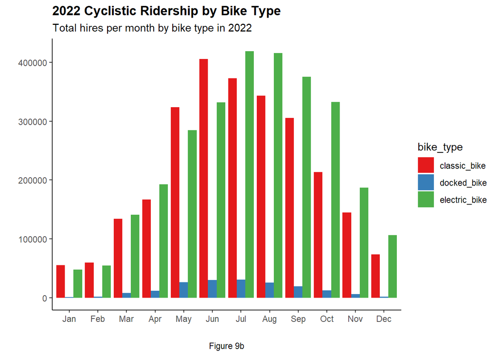

```r
  bike_type_month_summary %>%
  group_by(month, bike_type) %>%


  ggplot(aes(x = month, y = number_of_hires, fill = bike_type)) +
      geom_bar(stat = "identity", position = "dodge") +

        theme_classic() +
          labs(title = "2022 Cyclistic Ridership by Bike Type",
               subtitle = "Total hires per month by bike type in 2022",
               x = "",
               y = "",
               caption = "Figure 9b") +
          theme(plot.caption = element_text(hjust = 0.5),
          plot.title = element_text(face = "bold")) +
          scale_fill_brewer(palette = "Set1")
```

```r
ggsave("fig_9b_ridership_by_bike_type.jpg")
```

This would be easier to visualize on a line graph

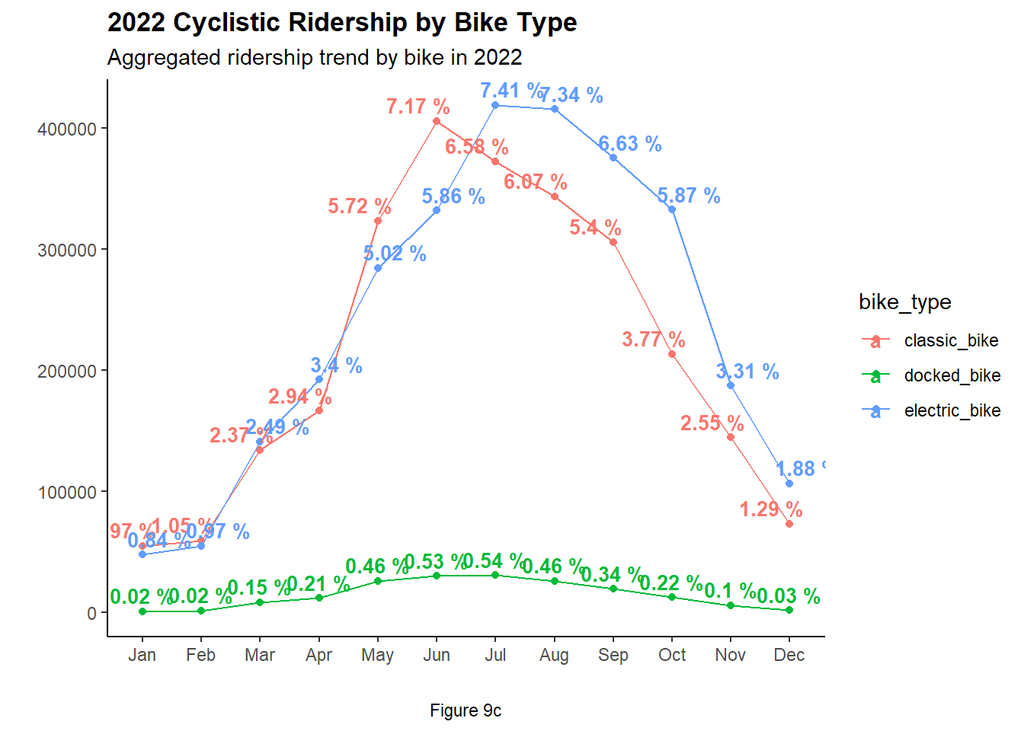

```r
options(scipen=999) # switch off scientific number format


  bike_type_month_summary %>%
    group_by(month) %>%
    ggplot(aes(x=month, y=number_of_hires, colour = bike_type)) +
    geom_point() +
    geom_line(aes(group = bike_type)) +
          geom_text(aes(label=paste0(Percentage_Split," %")), position=position_dodge(width=0.9), vjust=-0.50, size = 3.5, fontface = "bold") +

    theme_classic() +
          labs(title = "2022 Cyclistic Ridership by Bike Type",
              subtitle = "Aggregated ridership trend by bike in 2022",
              x = "",
              y = "",
              caption = "Figure 9c") +
              theme(plot.caption = element_text(hjust = 0.5),
                    plot.title = element_text(face = "bold")) +
              scale_fill_brewer(palette = "Set1")
```

```r
  ggsave("fig_9c_ridership_trend_by_bike_type.jpg")
```

**Bike Type Analysis Summary**

Bike type preference from the total of 5,661,759 bike hires in 2022 were as follows:

- 45.89 % Classic bikes (2,597,944)
- 51.03 % Electric bike (2,888,957)
- 3.09 % Docked bike (174,858)

There was a balanced ridership between classic and electric bikes, whereas docked bikes had the least of the three types.

2022 Bike Hire Preferences

Classic Bikes member 65.78 % 1,709,054  
casual 34.22 % 888,890

Electric Bikes member 56.63 % 1,635,897  
casual 43.37 % 1,253,060

Docked Bikes casual 100 % 174,858

Casual riders prefer electric bikes, followed by classic bikes and lastly docked bikes which only made 3% of the year’s total. Member riders has seen an almost balanced preference between classic and electric, leaning towards classic.

**Monthly Bike Type Preference Analysis**

We now break it down by months and user type

```r
 # We check the bike hires per month grouped by bike type and user type.

bike_type_month_sum_user <- trim_df %>%
  group_by(month, user_type, bike_type) %>%
  summarise(number_of_hires = n(),
            Percentage_Split = round(100 * n()/nrow(.), digits = 2)) %>%
            arrange(-Percentage_Split)

bike_type_month_sum_user
```

```
# A tibble: 60 × 5
# Groups:   month, user_type [24]
   month user_type bike_type     number_of_hires Percentage_Split
   <ord> <chr>     <chr>                   <int>            <dbl>
 1 Jun   member    classic_bike           236571             4.18
 2 Jul   casual    electric_bike          218902             3.87
 3 Jul   member    classic_bike           216994             3.83
 4 Aug   member    classic_bike           215328             3.8
 5 Aug   member    electric_bike          211585             3.74
 6 Aug   casual    electric_bike          203960             3.6
 7 Sep   member    electric_bike          203870             3.6
 8 Jul   member    electric_bike          200352             3.54
 9 Sep   member    classic_bike           200674             3.54
10 May   member    classic_bike           197899             3.5
# … with 50 more rows
```

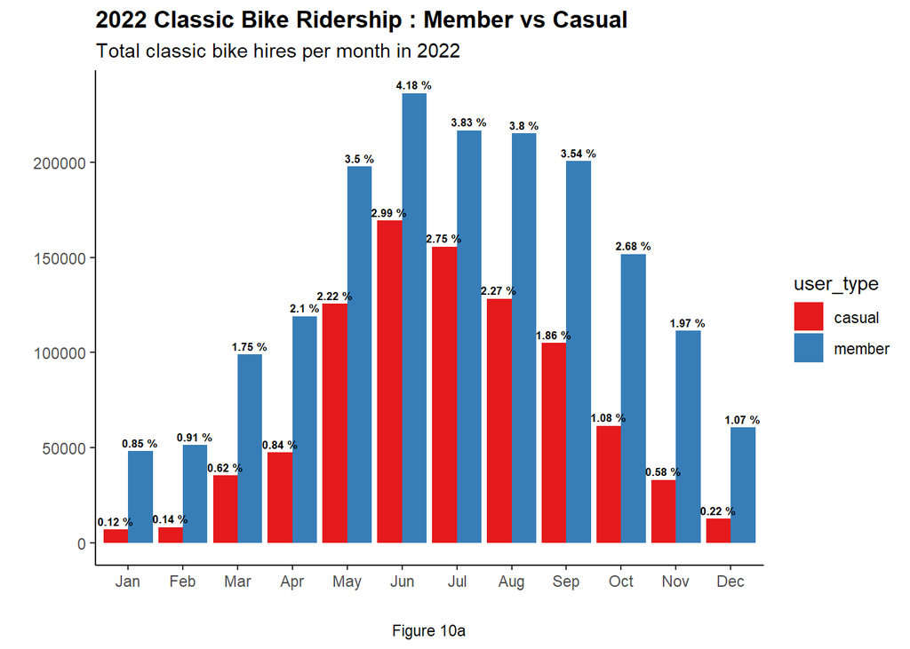

```r
bike_type_month_sum_user %>%
  filter(bike_type =="classic_bike") %>%
  group_by(month, user_type, bike_type) %>%


  ggplot(aes(x = month, y = number_of_hires, fill = user_type)) +
      geom_bar(stat = "identity", position = "dodge") +
          geom_text(aes(label=paste0(Percentage_Split," %")), position=position_dodge(width=0.9), vjust=-0.50, size = 2.2, fontface = "bold") +
         theme_classic() +
          labs(title = "2022 Classic Bike Ridership : Member vs Casual",
               subtitle = "Total classic bike hires per month in 2022",
               x = "",
               y = "",
               caption = "Figure 10a") +
          theme(plot.caption = element_text(hjust = 0.5),
          plot.title = element_text(face = "bold")) +
          scale_fill_brewer(palette = "Set1")
```

```r
ggsave("fig_10a_classic_bike_trend.jpg")
```

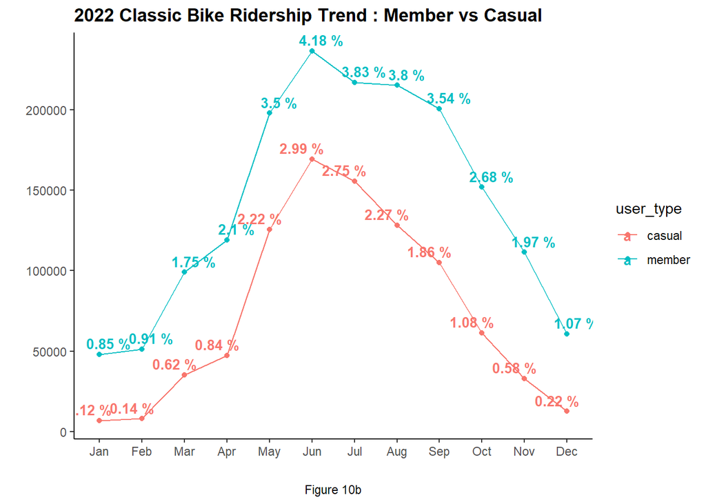

```r
options(scipen=999) # switch off scientific number format


  bike_type_month_sum_user %>%
    filter(bike_type =="classic_bike") %>%
    group_by(month) %>%
    ggplot(aes(x=month, y=number_of_hires, colour = user_type)) +
    geom_point() +
    geom_line(aes(group = user_type)) +
          geom_text(aes(label=paste0(Percentage_Split," %")), position=position_dodge(width=0.9), vjust=-0.50, size = 3.5, fontface = "bold") +

    theme_classic() +
          labs(title = "2022 Classic Bike Ridership Trend : Member vs Casual",
              x = "",
              y = "",
              caption = "Figure 10b") +
              theme(plot.caption = element_text(hjust = 0.5),
                    plot.title = element_text(face = "bold")) +
              scale_fill_brewer(palette = "Set1")
```

```r
  ggsave("fig_10b_classic_bike_trend.jpg")
```

We calculate the percentage split for classic bikes

```r
trim_df %>%
  filter(bike_type =="classic_bike") %>%
    group_by(user_type) %>%
      summarise(number_of_hires = n(),
                Percentage_Split = round(100 * n()/nrow(.), digits = 2)) %>%
            arrange(-Percentage_Split)
```

```
# A tibble: 2 × 3
  user_type number_of_hires Percentage_Split
  <chr>               <int>            <dbl>
1 member            1709054             65.8
2 casual             888890             34.2
```

We want the stats for classic bikes

```r
classic_monthly_stats <- trim_df %>%
    filter(bike_type=="classic_bike") %>%
      group_by(month, user_type) %>%
        summarise(avg_trip_dur = mean(trip_dur_sec),
                  number_of_hires = n(),
                  Percentage_Split = round(100 * n()/nrow(.), digits = 2))


  # max num hires - classic bikes
  classic_monthly_stats %>%
    group_by(user_type) %>%
      slice_max(number_of_hires)
```

```
# A tibble: 2 × 5
# Groups:   user_type [2]
  month user_type avg_trip_dur number_of_hires Percentage_Split
  <ord> <chr>            <dbl>           <int>            <dbl>
1 Jun   casual           1474.          169462             6.52
2 Jun   member            861.          236571             9.11
```

```r
  # min number of hires - classic bikes
  classic_monthly_stats %>%
      group_by(user_type) %>%
          slice_min(number_of_hires)
```

```
# A tibble: 2 × 5
# Groups:   user_type [2]
  month user_type avg_trip_dur number_of_hires Percentage_Split
  <ord> <chr>            <dbl>           <int>            <dbl>
1 Jan   casual           1342.            6935             0.27
2 Jan   member            754.           48064             1.85
```

```r
  # max avg trip duration - classic bikes
  classic_monthly_stats %>%
      group_by(user_type) %>%
          slice_max(avg_trip_dur)
```

```
# A tibble: 2 × 5
# Groups:   user_type [2]
  month user_type avg_trip_dur number_of_hires Percentage_Split
  <ord> <chr>            <dbl>           <int>            <dbl>
1 Mar   casual           1666.           35284             1.36
2 Jul   member            864.          216994             8.35
```

```r
  # min avg trip duration - classic bikes
  classic_monthly_stats %>%
      group_by(user_type) %>%
          slice_min(avg_trip_dur)
```

```
# A tibble: 2 × 5
# Groups:   user_type [2]
  month user_type avg_trip_dur number_of_hires Percentage_Split
  <ord> <chr>            <dbl>           <int>            <dbl>
1 Dec   casual           1063.           12602             0.49
2 Dec   member            657.           60673             2.34
```

**Summary - Classic Bike**

Classic Bikes member 65.78 % 1,709,054  
casual 34.22 % 888,890

Maximum number of hires Jun casual 1474 s 169,462 6.52 % Jun member 861 s 236,571 9.11 %

Minimum number of hires Jan casual 1342 s 6935 0.27 % Jan member 753 s 48,064 1.85 %

Longest average trip duration Mar casual 1666 s 35284 1.36 % Jul member 864 s 216994 8.35 %

Shortest average trip duration Dec casual 1063 s 12,602 0.49 % Dec member 657 s 60,673 2.34 %

**Electric Bike Stats**

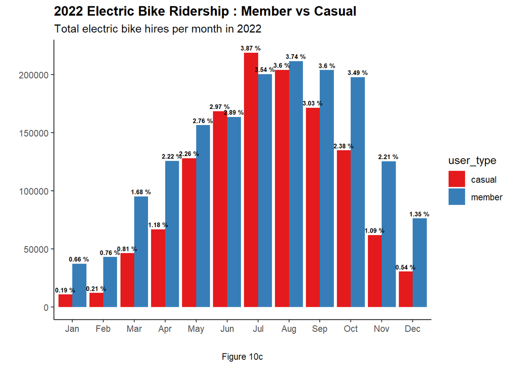

```r
bike_type_month_sum_user %>%
  filter(bike_type =="electric_bike") %>%
  group_by(month, user_type, bike_type) %>%


  ggplot(aes(x = month, y = number_of_hires, fill = user_type)) +
      geom_bar(stat = "identity", position = "dodge") +
          geom_text(aes(label=paste0(Percentage_Split," %")), position=position_dodge(width=0.9), vjust=-0.50, size = 2.2, fontface = "bold") +
         theme_classic() +
          labs(title = "2022 Electric Bike Ridership : Member vs Casual",
               subtitle = "Total electric bike hires per month in 2022",
               x = "",
               y = "",
               caption = "Figure 10c") +
          theme(plot.caption = element_text(hjust = 0.5),
          plot.title = element_text(face = "bold")) +
          scale_fill_brewer(palette = "Set1")
```

```r
ggsave("fig_10c_electric_bike_trend.jpg")
```

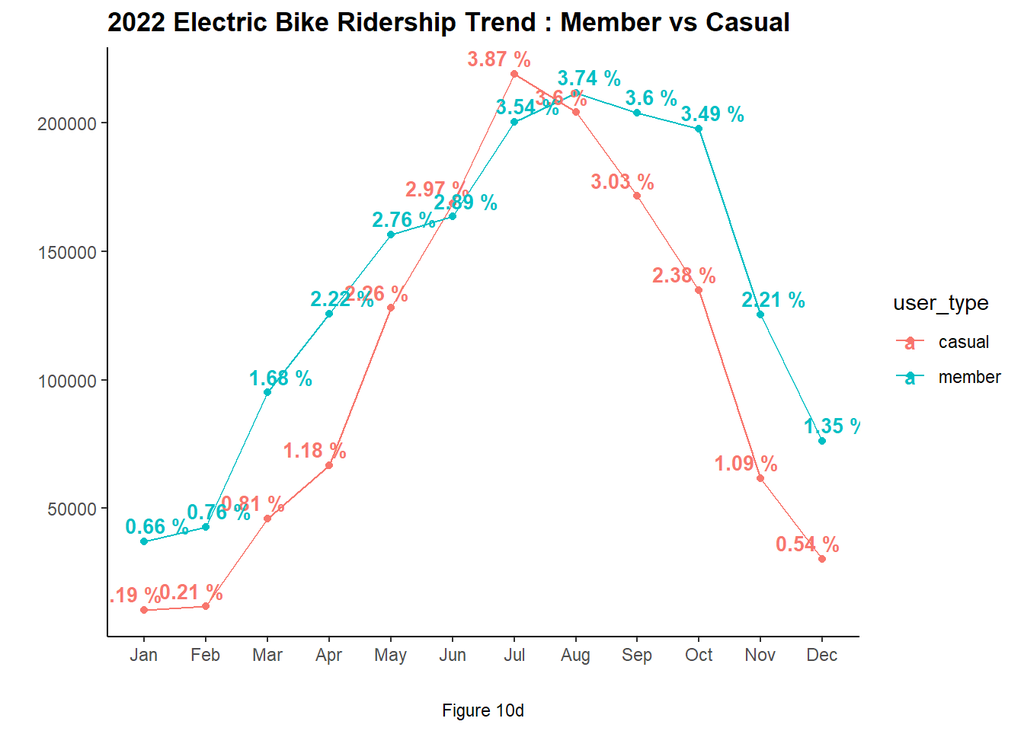

```r
options(scipen=999) # switch off scientific number format


  bike_type_month_sum_user %>%
    filter(bike_type =="electric_bike") %>%
    group_by(month) %>%
    ggplot(aes(x=month, y=number_of_hires, colour = user_type)) +
    geom_point() +
    geom_line(aes(group = user_type)) +
          geom_text(aes(label=paste0(Percentage_Split," %")), position=position_dodge(width=0.9), vjust=-0.50, size = 3.5, fontface = "bold") +

    theme_classic() +
          labs(title = "2022 Electric Bike Ridership Trend : Member vs Casual",
              x = "",
              y = "",
              caption = "Figure 10d") +
              theme(plot.caption = element_text(hjust = 0.5),
                    plot.title = element_text(face = "bold")) +
              scale_fill_brewer(palette = "Set1")
```

```r
  ggsave("fig_10d_electric_bike_trend.jpg")
```

```r
trim_df %>%
  filter(bike_type =="electric_bike") %>%
    group_by(user_type) %>%
      summarise(number_of_hires = n(),
                Percentage_Split = round(100 * n()/nrow(.), digits = 2)) %>%
            arrange(-Percentage_Split)
```

```
# A tibble: 2 × 3
  user_type number_of_hires Percentage_Split
  <chr>               <int>            <dbl>
1 member            1635897             56.6
2 casual            1253060             43.4
```

```r
electric_monthly_stats <- trim_df %>%
    filter(bike_type=="electric_bike") %>%
      group_by(month, user_type) %>%
        summarise(avg_trip_dur = mean(trip_dur_sec),
                  number_of_hires = n(),
                  Percentage_Split = round(100 * n()/nrow(.), digits = 2))


  # max num hires - electric bikes
  electric_monthly_stats %>%
    group_by(user_type) %>%
      slice_max(number_of_hires)
```

```
# A tibble: 2 × 5
# Groups:   user_type [2]
  month user_type avg_trip_dur number_of_hires Percentage_Split
  <ord> <chr>            <dbl>           <int>            <dbl>
1 Jul   casual           1071.          218902             7.58
2 Aug   member            729.          211585             7.32
```

```r
  # min number of hires - electric bikes
  electric_monthly_stats %>%
      group_by(user_type) %>%
          slice_min(number_of_hires)
```

```
# A tibble: 2 × 5
# Groups:   user_type [2]
  month user_type avg_trip_dur number_of_hires Percentage_Split
  <ord> <chr>            <dbl>           <int>            <dbl>
1 Jan   casual            763.           10585             0.37
2 Jan   member            623.           37157             1.29
```

```r
  # max avg trip duration - electric bikes
  electric_monthly_stats %>%
      group_by(user_type) %>%
          slice_max(avg_trip_dur)
```

```
# A tibble: 2 × 5
# Groups:   user_type [2]
  month user_type avg_trip_dur number_of_hires Percentage_Split
  <ord> <chr>            <dbl>           <int>            <dbl>
1 May   casual           1108.          127930             4.43
2 Jun   member            758.          163484             5.66
```

```r
  # min avg trip duration - electric bikes
  electric_monthly_stats %>%
      group_by(user_type) %>%
          slice_min(avg_trip_dur)
```

```
# A tibble: 2 × 5
# Groups:   user_type [2]
  month user_type avg_trip_dur number_of_hires Percentage_Split
  <ord> <chr>            <dbl>           <int>            <dbl>
1 Dec   casual            604.           30317             1.05
2 Dec   member            593.           76214             2.64
```

**Summary - Electric Bike**

Electric Bikes member 56.63 % 1,635,897  
casual 43.37 % 1,253,060

Maximum number of hires Jul casual 1071 s 218,902 7.58 % Aug member 729 s 211,585 7.32 %

Minimum number of hires Jan casual 763 s 10,585 0.37 % Jan member 622 s 37,157 1.29 %

Longest average trip duration May casual 1108 s 127,930 4.43 % Jun member 758 s 163,484 5.66 %

Shortest average trip duration Dec casual 604 s 30,317 1.05 % Dec member 592 s 76,214 2.64 %

**Docked Bike Stats**

```r
trim_df %>%
  filter(bike_type =="docked_bike") %>%
    group_by(user_type) %>%
      summarise(number_of_hires = n(),
                Percentage_Split = round(100 * n()/nrow(.), digits = 2)) %>%
            arrange(-Percentage_Split)
```

```
# A tibble: 1 × 3
  user_type number_of_hires Percentage_Split
  <chr>               <int>            <dbl>
1 casual             174858              100
```

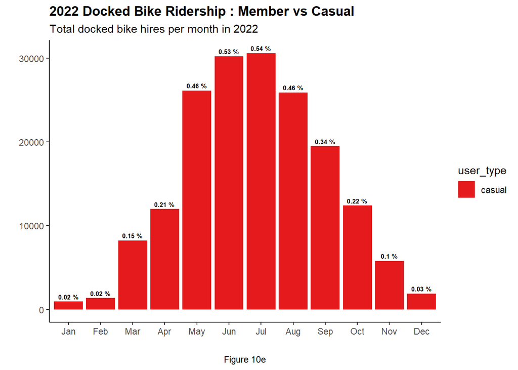

```r
bike_type_month_sum_user %>%
  filter(bike_type =="docked_bike") %>%
  group_by(month, user_type, bike_type) %>%


  ggplot(aes(x = month, y = number_of_hires, fill = user_type)) +
      geom_bar(stat = "identity", position = "dodge") +
          geom_text(aes(label=paste0(Percentage_Split," %")), position=position_dodge(width=0.9), vjust=-0.50, size = 2.2, fontface = "bold") +
         theme_classic() +
          labs(title = "2022 Docked Bike Ridership : Member vs Casual",
               subtitle = "Total docked bike hires per month in 2022",
               x = "",
               y = "",
               caption = "Figure 10e") +
          theme(plot.caption = element_text(hjust = 0.5),
          plot.title = element_text(face = "bold")) +
          scale_fill_brewer(palette = "Set1")
```

```r
ggsave("fig_10e_docked_bike_trend.jpg")
```

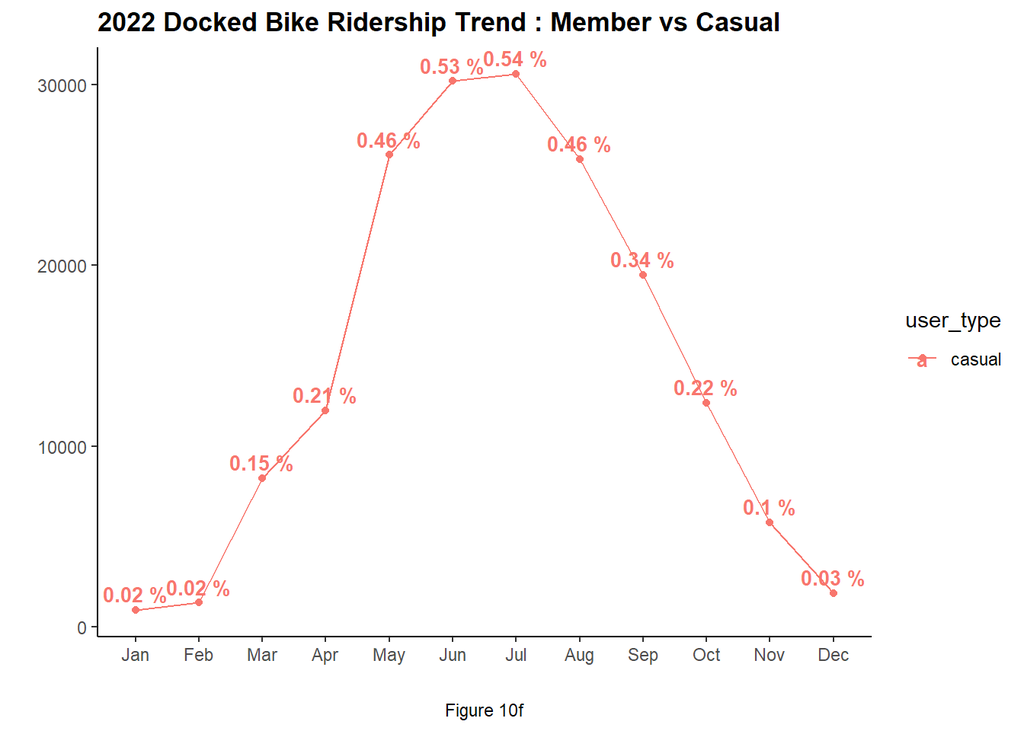

```r
options(scipen=999) # switch off scientific number format


  bike_type_month_sum_user %>%
    filter(bike_type =="docked_bike") %>%
    group_by(month) %>%
    ggplot(aes(x=month, y=number_of_hires, colour = user_type)) +
    geom_point() +
    geom_line(aes(group = user_type)) +
          geom_text(aes(label=paste0(Percentage_Split," %")), position=position_dodge(width=0.9), vjust=-0.50, size = 3.5, fontface = "bold") +

    theme_classic() +
          labs(title = "2022 Docked Bike Ridership Trend : Member vs Casual",
              x = "",
              y = "",
              caption = "Figure 10f") +
              theme(plot.caption = element_text(hjust = 0.5),
                    plot.title = element_text(face = "bold")) +
              scale_fill_brewer(palette = "Set1")
```

```r
  ggsave("fig_10f_docked_bike_trend.jpg")
```

```r
docked_monthly_stats <- trim_df %>%
    filter(bike_type=="docked_bike") %>%
      group_by(month, user_type) %>%
        summarise(avg_trip_dur = mean(trip_dur_sec),
                  number_of_hires = n(),
                  Percentage_Split = round(100 * n()/nrow(.), digits = 2))


  # max num hires - docked bikes
  docked_monthly_stats %>%
    group_by(user_type) %>%
      slice_max(number_of_hires)
```

```
# A tibble: 1 × 5
# Groups:   user_type [1]
  month user_type avg_trip_dur number_of_hires Percentage_Split
  <ord> <chr>            <dbl>           <int>            <dbl>
1 Jul   casual           3256.           30599             17.5
```

```r
  # min number of hires - docked bikes
  docked_monthly_stats %>%
      group_by(user_type) %>%
          slice_min(number_of_hires)
```

```
# A tibble: 1 × 5
# Groups:   user_type [1]
  month user_type avg_trip_dur number_of_hires Percentage_Split
  <ord> <chr>            <dbl>           <int>            <dbl>
1 Jan   casual           9452.             943             0.54
```

```r
  # max avg trip duration - docked bikes
  docked_monthly_stats %>%
      group_by(user_type) %>%
          slice_max(avg_trip_dur)
```

```
# A tibble: 1 × 5
# Groups:   user_type [1]
  month user_type avg_trip_dur number_of_hires Percentage_Split
  <ord> <chr>            <dbl>           <int>            <dbl>
1 Jan   casual           9452.             943             0.54
```

```r
  # min avg trip duration - docked bikes
  docked_monthly_stats %>%
      group_by(user_type) %>%
          slice_min(avg_trip_dur)
```

```
# A tibble: 1 × 5
# Groups:   user_type [1]
  month user_type avg_trip_dur number_of_hires Percentage_Split
  <ord> <chr>            <dbl>           <int>            <dbl>
1 Dec   casual           2290.            1872             1.07
```

**Summary - Docked Bike**

Docked Bikes casual 100 % 174,858

Maximum number of hires Jul casual 3255 s 30,599 17.5 %

Minimum number of hires Jan casual 9451 s 943 0.54 %

Longest average trip duration Jan casual 9451 s 943 0.54 %

Shortest average trip duration Dec casual 2290 s 1872 1.07 %

**Weekday Bike Preference Analysis**

Let us examine the maximum and minimum bike usage per weekday by bike type

```r
  # table

  bike_type_usage_weekday  <- trim_df %>%
  group_by(weekday, user_type, bike_type) %>%
  summarise(number_of_hires = n(),
            Percentage_Split = round(100 * n()/nrow(.), digits = 2)) %>%
            arrange(-Percentage_Split)

  bike_type_usage_weekday %>%
          group_by(user_type, bike_type) %>%
            slice_max(number_of_hires)
```

```
# A tibble: 5 × 5
# Groups:   user_type, bike_type [5]
  weekday user_type bike_type     number_of_hires Percentage_Split
  <ord>   <chr>     <chr>                   <int>            <dbl>
1 Sat     casual    classic_bike           196668             3.47
2 Sat     casual    docked_bike             40356             0.71
3 Sat     casual    electric_bike          235058             4.15
4 Tue     member    classic_bike           268251             4.74
5 Thu     member    electric_bike          264801             4.68
```

```r
  bike_type_usage_weekday %>%
          group_by(user_type, bike_type) %>%
            slice_min(number_of_hires)
```

```
# A tibble: 5 × 5
# Groups:   user_type, bike_type [5]
  weekday user_type bike_type     number_of_hires Percentage_Split
  <ord>   <chr>     <chr>                   <int>            <dbl>
1 Tue     casual    classic_bike            95820             1.69
2 Wed     casual    docked_bike             17097             0.3
3 Tue     casual    electric_bike          149856             2.65
4 Sun     member    classic_bike           200994             3.55
5 Sun     member    electric_bike          186123             3.29
```

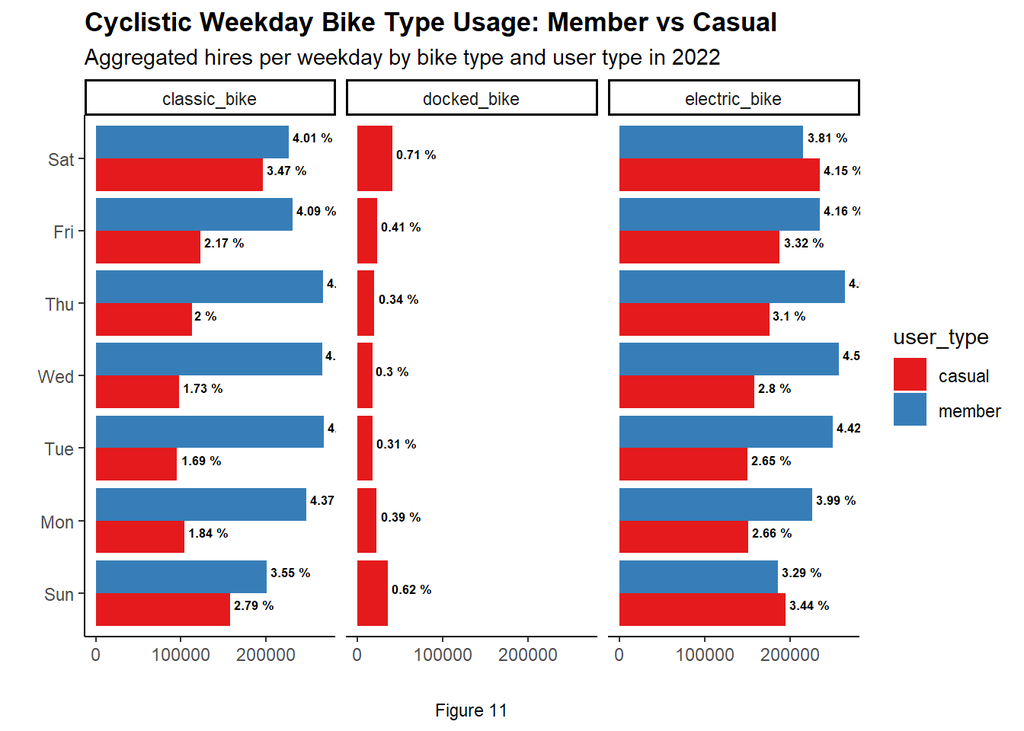

```r
  # graph
  bike_type_usage_weekday %>%
  group_by(weekday, user_type, bike_type) %>%

  ggplot(aes(x = weekday, y = number_of_hires, fill = user_type)) +
          geom_col(position = "dodge") +
          facet_grid(~bike_type) +
          coord_flip() +
          geom_text(aes(label=paste0(Percentage_Split," %")), position=position_dodge(width=0.9), hjust = - 0.10, vjust=-0.00, size = 2.2, fontface = "bold") +
            theme_classic() +
              labs(title = "Cyclistic Weekday Bike Type Usage: Member vs Casual",
                  subtitle = "Aggregated hires per weekday by bike type and user type in 2022",
                  x = "",
                  y = "",
                  caption = "Figure 11") +
              theme(plot.caption = element_text(hjust = 0.5),
              plot.title = element_text(face = "bold")) +
              scale_fill_brewer(palette = "Set1")
```

```r
ggsave("fig_11_weekday_usage_bike_type.jpg")
```

**Busiest days**

Sat casual classic_bike 196,668 3.47 % Tue member classic_bike 268,251 4.74 %

Thu member electric_bike 264,801 4.68 % Sat casual electric_bike 235,058 4.15 %

Sat casual docked_bike 40,356 0.71 %

**Least busiest days**

Tue casual classic_bike 95,820 1.69 % Sun member classic_bike 200,994 3.55 %

Tue casual electric_bike 149,856 2.65 % Sun member electric_bike 186,123 3.29 %

Wed casual docked_bike 17,097 0.30 %

**Bike Usage by Type**

Let us see how casual users prefer to use the=ir bikes over the year

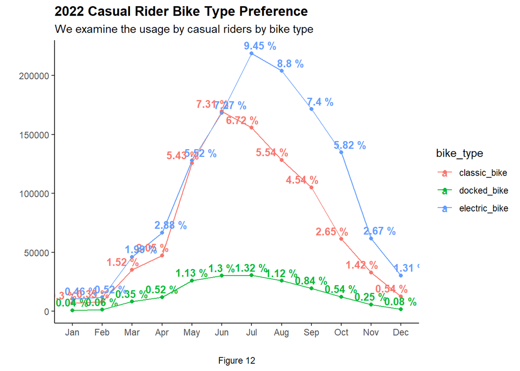

```r
options(scipen=999) # switch off scientific number format

bike_summary_casual <- trim_df %>%
      filter(user_type=="casual") %>%
        group_by(month, bike_type) %>%
            summarise(number_of_hires = n(),
            Percentage_Split = round(100 * n()/nrow(.), digits = 2)) %>%
            arrange(-Percentage_Split)


bike_summary_casual %>%
    group_by(month) %>%
    ggplot(aes(x=month, y=number_of_hires, colour = bike_type)) +
    geom_point() +
    geom_line(aes(group = bike_type)) +
          geom_text(aes(label=paste0(Percentage_Split," %")), position=position_dodge(width=0.9), vjust=-0.50, size = 3.5, fontface = "bold") +

    theme_classic() +
          labs(title = "2022 Casual Rider Bike Type Preference",
              subtitle = "We examine the usage by casual riders by bike type",
              x = "",
              y = "",
              caption = "Figure 12") +
              theme(plot.caption = element_text(hjust = 0.5),
                    plot.title = element_text(face = "bold")) +
              scale_fill_brewer(palette = "Set1")
```

```r
  ggsave("fig_12_casual_bike_type_usage.jpg")
```

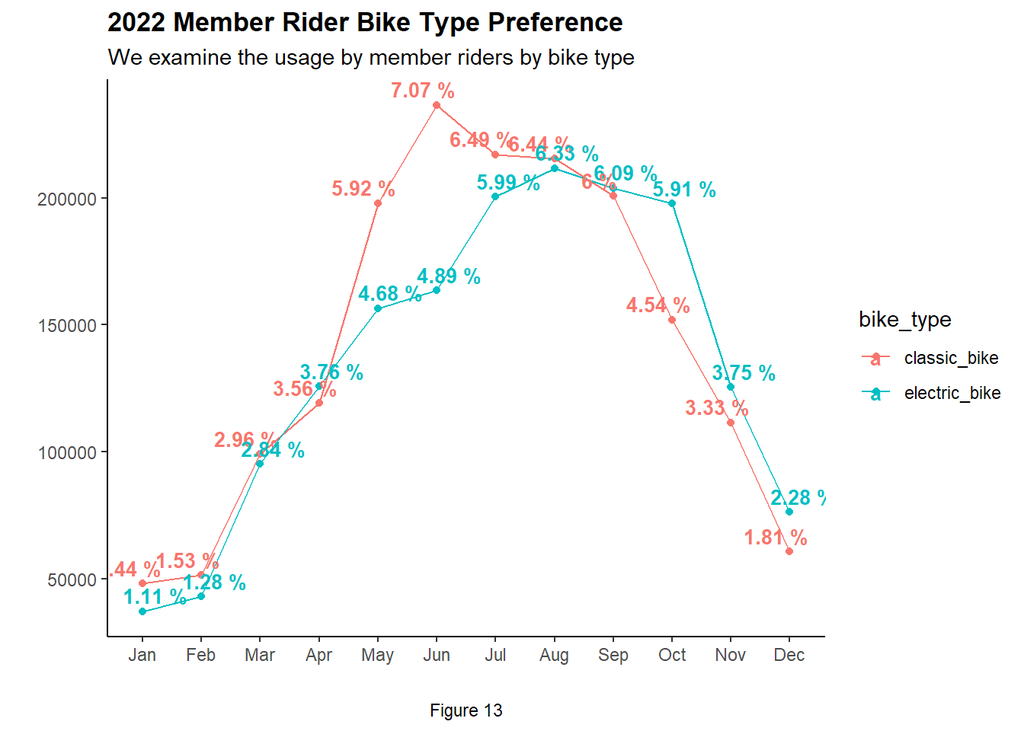

```r
options(scipen=999) # switch off scientific number format

member_summary_casual <- trim_df %>%
      filter(user_type=="member") %>%
        group_by(month, bike_type) %>%
            summarise(number_of_hires = n(),
            Percentage_Split = round(100 * n()/nrow(.), digits = 2)) %>%
            arrange(-Percentage_Split)


member_summary_casual %>%
    group_by(month) %>%
    ggplot(aes(x=month, y=number_of_hires, colour = bike_type)) +
    geom_point() +
    geom_line(aes(group = bike_type)) +
          geom_text(aes(label=paste0(Percentage_Split," %")), position=position_dodge(width=0.9), vjust=-0.50, size = 3.5, fontface = "bold") +

    theme_classic() +
          labs(title = "2022 Member Rider Bike Type Preference",
              subtitle = "We examine the usage by member riders by bike type",
              x = "",
              y = "",
              caption = "Figure 13") +
              theme(plot.caption = element_text(hjust = 0.5),
                    plot.title = element_text(face = "bold")) +
              scale_fill_brewer(palette = "Set1")
```

```r
  ggsave("fig_13_casual_bike_type_usage.jpg")
```

**Bike Preference Analysis Summary**

**Casual Riders**

Casual users prefer electric bikes overall

The highest hires

- electric bikes : July (9.45 %)
- classic bikes : June (7,31 %)
- docked bikes : July (1.32 %)

The lowest hires for all types of bikes was in January

**Member Riders**

Member have shown an equal preference for classic and electric bikes

There is an approximately balanced hire trend between classic and electric bikes.

The lowest hires for both types of bikes was in January

**5. Export summary files for further analysis**

```r
# If further analysis is required in a different package these subsets can be exported
# for now we leave them commented out because trim_df cover all the data that may be required

# write.csv(monthly_trip_dur_stats, file='monthly_trip_dur_stats.csv')
# write.csv(monthly_ridership, file='monthly_ridership.csv')
# write.csv(monthly_median_trip_dur, file='monthly_median_trip_dur.csv')
# write.csv(monthly_avg_trip_dur, file='monthly_avg_trip_dur.csv')
# write.csv(hourly_ridership, file='hourly_ridership_stats.csv')
# write.csv(bike_type_usage_weekday, file='bike_type_usage_weekday.csv')
# write.csv(bike_type_usage, file='bike_type_usage.csv')
# write.csv(bike_type_stats, file='bike_type_stats.csv')
# write.csv(bike_type_month_summary, file='bike_type_month_summary.csv')
# write.csv(bike_type_by_user, file='bike_type_by_user.csv')


# we shall export this dataset as per the Google Certification requirement
counts <- aggregate(trim_df$trip_dur_sec ~ trim_df$user_type + trim_df$weekday, FUN = mean)
write.csv(counts, file = 'avg_ride_length.csv')


# close the dataframe
rm(counts)

# we will also export the trimmed dataframe for further analysis regarding other metrics
write.csv(trim_df, file = 'trimmed_trip_data_clean_2022.csv')
```

### **Analysis Summary**

- 29.9% were weekend hires, 15 % casual riders and 14.7 % member riders
- 26.6 % of hires were for commuting*, 17.9 % are member riders and 8.79% are casual riders
- On average, casual riders have 77% longer trips than member riders
- There were 18 % more member riders than casual riders
- Member users maintained a steady average trip duration throughout the year, whereas the casual riders had a higher trip duration during the summer months which then dropped from Jun to Dec by 50%. This suggests that casual riders use their bikes for leisure and members for commuting.
- April to October had 82 % of total ridership : 46% member riders and 36 % casual riders

# **Phase 5 : Share**

This is the google slides presentation for the stakeholders [Cyclistic Data Analysis](https://docs.google.com/presentation/d/1KnZvq5_AJy-ahMy5ytyW2xVKi3lid5JcbxVyFQHtKYI/edit?usp=sharing)

# **Phase 6 : Act**

## **Conclusion**

The aim of this study was to see how casual and membership riders use their bikes differently. The purpose was to see if it is feasible to design a marketing campaign to convert casual users to a annual membership subscription.

The data was analysed and the top three findings were:

1. 26.6 % of hires were for commuting*, 17.9 % are member riders and 8.79% are casual riders
2. 29.9% were weekend hires, 15 % casual riders and 14.7 % member riders, both follow almost the same usage pattern
3. Casual users prefer electric bikes and weekend hires, they mainly use their bikes for leisure.

**Action**

If casual users were to convert over to membership, they would have to use the bikes regularly to reap the benefits of an annual membership subscription.

Based on the results of this study, we see that casual users who make the daily commute, that would be 8.79% of the total ridership, would benefit the most from the annual subscription as it would save them money. This is based on the assumption that casual users who hire out the bikes during commuting hours and days are using them for that purpose alone.

It is also shown that casual usage of bikes, mainly electric peak in summer months, where a weekend trip duration is longer than member riders. Casual riders who regularly make weekend trips would benefit from the annual membership plan, as it would save them money in the long run.

**Conclusion**

The segment of casual riders who:

- make the daily commute
- regular weekend leisure trips

**Further Analysis**

The data does not show how frequently casual users use their bikes. To gain these insights we will need to analyse financial information which will tell us if any casual users have made repeated hires and over what period.